# Using Classification algorithms in financial markets (Stock Market Prediction)

Mohammad Ali Momen

05/10/2023

**Data Analysis methodology**: CRISP-DM

**Dataset**: S&P-500 (The Standard and Poor’s 500) Timeseries data from 2019 to 2022

**Case Goal**: Create an automatic financial trading algorithm for S&P-500 index (Algorithmic Trading)

# 1 Required Libraries

```r
library('ggplot2')
library('quantmod')
library('TTR')
library('e1071')
```

# 2 Get financial market historical Data from Internet

```r
quantmod::getSymbols(Symbols = '^GSPC', from = '2019-01-01', to = '2022-12-31', periodicity = 'daily', src = 'yahoo')  # load Historical data of S&P-500 from Yahoo Finance API
```

```
## [1] "GSPC"
```

```r
dim(GSPC)  # 1008 records, 6 variables
```

```
## [1] 1008    6
```

# 3 Business Understanding

- know business process and issues
- know the context of the problem
- know the order of numbers in the business
- What we will do in this case:
  - first, we make a hypothesis about market
  - then, convert this hypothesis to an algorithm
  - then, measure this algorithm performance on Test data
  - then, use this algorithm for prediction (predict market direction -> 0: price will fall, 1: price will raise)
  - then, make a Decision-Rule based-on these predictions
  - finally, do trade via this Decision-Rule
  - now, we have a Trading Algorithm
- S&P-500 (Standard and Poor 500):
  - an index of USA stock market
  - is a stock market index that measures the stock performance of 500 large companies listed on stock exchanges in the USA
  - it shows total direction of NASDAQ market
  - we want to Trade on changes of S&P-500

# 4 Data Understanding

## 4.1 Data Inspection

Data Understanding from Free Perspective

### 4.1.1 Dataset variables definition

```r
colnames(GSPC)
```

```
## [1] "GSPC.Open"     "GSPC.High"     "GSPC.Low"      "GSPC.Close"
## [5] "GSPC.Volume"   "GSPC.Adjusted"
```

- **Index**: the Timestamp of record (date)
- **Open**: the price of asset at market opening (start of day)
- **High**: the maximum price of asset in a day
- **Low**: the minimum price of asset in a day
- **Close**: the price of asset at market closing (end of day)
- **Volume**: the trading volume of asset in a day
- **Adjusted**:

## 4.2 Data Exploring

Data Understanding from Statistical Perspective

### 4.2.1 Overview of Dataframe

```r
class(GSPC)
```

```
## [1] "xts" "zoo"
```

```r
head(GSPC)
```

```
##            GSPC.Open GSPC.High GSPC.Low GSPC.Close GSPC.Volume GSPC.Adjusted
## 2019-01-02   2476.96   2519.49  2467.47    2510.03  3733160000       2510.03
## 2019-01-03   2491.92   2493.14  2443.96    2447.89  3858830000       2447.89
## 2019-01-04   2474.33   2538.07  2474.33    2531.94  4234140000       2531.94
## 2019-01-07   2535.61   2566.16  2524.56    2549.69  4133120000       2549.69
## 2019-01-08   2568.11   2579.82  2547.56    2574.41  4120060000       2574.41
## 2019-01-09   2580.00   2595.32  2568.89    2584.96  4088740000       2584.96
```

```r
tail(GSPC)
```

```
##            GSPC.Open GSPC.High GSPC.Low GSPC.Close GSPC.Volume GSPC.Adjusted
## 2022-12-22   3853.26   3853.26  3764.49    3822.39  3956950000       3822.39
## 2022-12-23   3815.11   3845.80  3797.01    3844.82  2819280000       3844.82
## 2022-12-27   3843.34   3846.65  3813.22    3829.25  3030300000       3829.25
## 2022-12-28   3829.56   3848.32  3780.78    3783.22  3083520000       3783.22
## 2022-12-29   3805.45   3858.19  3805.45    3849.28  3003680000       3849.28
## 2022-12-30   3829.06   3839.85  3800.34    3839.50  2979870000       3839.50
```

```r
dim(GSPC)
```

```
## [1] 1008    6
```

```r
summary(GSPC)
```

```
##      Index              GSPC.Open      GSPC.High       GSPC.Low
##  Min.   :2019-01-02   Min.   :2291   Min.   :2301   Min.   :2192
##  1st Qu.:2020-01-01   1st Qu.:3005   1st Qu.:3016   1st Qu.:2991
##  Median :2020-12-30   Median :3685   Median :3707   Median :3647
##  Mean   :2020-12-31   Mean   :3624   Mean   :3647   Mean   :3600
##  3rd Qu.:2021-12-30   3rd Qu.:4182   3rd Qu.:4203   3rd Qu.:4159
##  Max.   :2022-12-30   Max.   :4805   Max.   :4819   Max.   :4780
##    GSPC.Close    GSPC.Volume        GSPC.Adjusted
##  Min.   :2237   Min.   :1.297e+09   Min.   :2237
##  1st Qu.:3005   1st Qu.:3.674e+09   1st Qu.:3005
##  Median :3678   Median :4.134e+09   Median :3678
##  Mean   :3625   Mean   :4.379e+09   Mean   :3625
##  3rd Qu.:4180   3rd Qu.:4.818e+09   3rd Qu.:4180
##  Max.   :4797   Max.   :9.977e+09   Max.   :4797
```

```r
GSPC
```

```
##            GSPC.Open GSPC.High GSPC.Low GSPC.Close GSPC.Volume GSPC.Adjusted
## 2019-01-02   2476.96   2519.49  2467.47    2510.03  3733160000       2510.03
## 2019-01-03   2491.92   2493.14  2443.96    2447.89  3858830000       2447.89
## 2019-01-04   2474.33   2538.07  2474.33    2531.94  4234140000       2531.94
## 2019-01-07   2535.61   2566.16  2524.56    2549.69  4133120000       2549.69
## 2019-01-08   2568.11   2579.82  2547.56    2574.41  4120060000       2574.41
## 2019-01-09   2580.00   2595.32  2568.89    2584.96  4088740000       2584.96
## 2019-01-10   2573.51   2597.82  2562.02    2596.64  3721300000       2596.64
## 2019-01-11   2588.11   2596.27  2577.40    2596.26  3447460000       2596.26
## 2019-01-14   2580.31   2589.32  2570.41    2582.61  3689370000       2582.61
## 2019-01-15   2585.10   2613.08  2585.10    2610.30  3601180000       2610.30
##        ...
## 2022-12-16   3890.91   3890.91  3827.91    3852.36  7493660000       3852.36
## 2022-12-19   3853.79   3854.86  3800.04    3817.66  3969610000       3817.66
## 2022-12-20   3810.47   3838.24  3795.62    3821.62  3985370000       3821.62
## 2022-12-21   3839.49   3889.82  3839.49    3878.44  3775200000       3878.44
## 2022-12-22   3853.26   3853.26  3764.49    3822.39  3956950000       3822.39
## 2022-12-23   3815.11   3845.80  3797.01    3844.82  2819280000       3844.82
## 2022-12-27   3843.34   3846.65  3813.22    3829.25  3030300000       3829.25
## 2022-12-28   3829.56   3848.32  3780.78    3783.22  3083520000       3783.22
## 2022-12-29   3805.45   3858.19  3805.45    3849.28  3003680000       3849.28
## 2022-12-30   3829.06   3839.85  3800.34    3839.50  2979870000       3839.50
```

### 4.2.2 Data Visualization

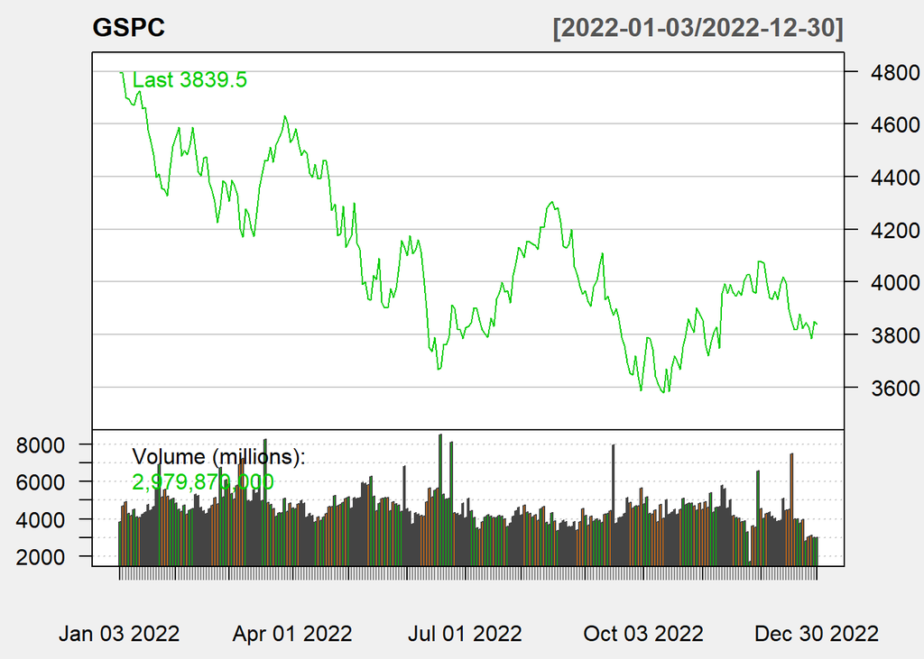

```r
chartSeries(GSPC, type = 'line', subset = '2022', theme = chartTheme('white'))  # S&P-500 price changes through time in 2022
```

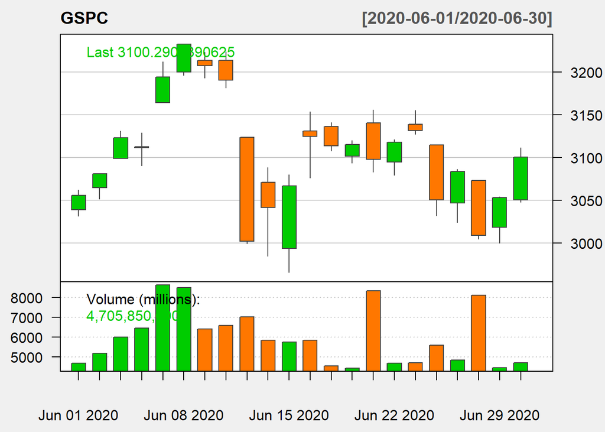

```r
chartSeries(GSPC, type = 'candlesticks', subset = '2020-6', theme = chartTheme('white'))
```

### 4.2.3 Technical Indicators

#### 4.2.3.1 Simple Moving Average (SMA)

```r
sma <- TTR::SMA(Cl(GSPC), n = 20)  # calculate SMA-20 for each day on Close price
head(sma)
```

```
##            SMA
## 2019-01-02  NA
## 2019-01-03  NA
## 2019-01-04  NA
## 2019-01-07  NA
## 2019-01-08  NA
## 2019-01-09  NA
```

```r
tail(sma)
```

```
##                 SMA
## 2022-12-22 3952.086
## 2022-12-23 3943.021
## 2022-12-27 3936.287
## 2022-12-28 3927.567
## 2022-12-29 3916.025
## 2022-12-30 3904.171
```

#### 4.2.3.2 Exponential Moving Average (EMA)

```r
ema <- TTR::EMA(Cl(GSPC), n = 20)  # calculate EMA-20 for each day on Close price
head(ema)
```

```
##            EMA
## 2019-01-02  NA
## 2019-01-03  NA
## 2019-01-04  NA
## 2019-01-07  NA
## 2019-01-08  NA
## 2019-01-09  NA
```

```r
tail(ema)
```

```
##                 EMA
## 2022-12-22 3914.068
## 2022-12-23 3907.473
## 2022-12-27 3900.023
## 2022-12-28 3888.899
## 2022-12-29 3885.126
## 2022-12-30 3880.780
```

#### 4.2.3.3 Relative Strength Index (RSI)

```r
rsi <- TTR::RSI(Cl(GSPC), n = 14)  # calculate RSI-14 for each day on Close price
head(rsi)
```

```
##            rsi
## 2019-01-02  NA
## 2019-01-03  NA
## 2019-01-04  NA
## 2019-01-07  NA
## 2019-01-08  NA
## 2019-01-09  NA
```

```r
tail(rsi)
```

```
##                 rsi
## 2022-12-22 41.56677
## 2022-12-23 43.85289
## 2022-12-27 42.60677
## 2022-12-28 39.07199
## 2022-12-29 45.99649
## 2022-12-30 45.17787
```

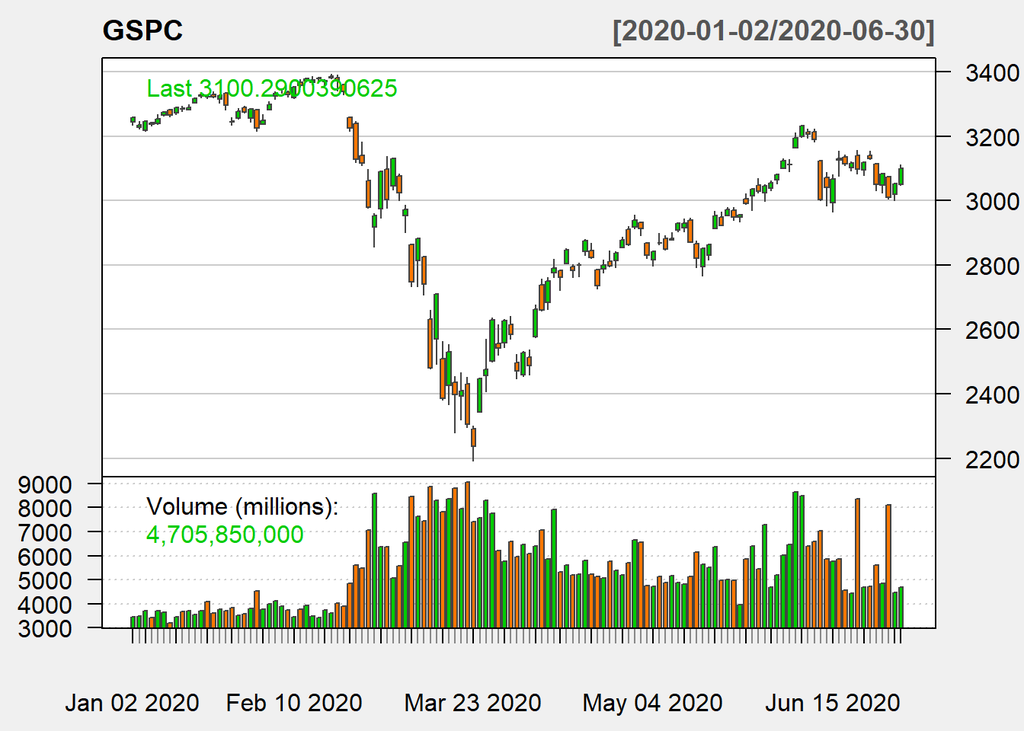

```r
chartSeries(GSPC, type = 'candlesticks', subset = '2020-01::2020-06', theme = chartTheme('white'))
```

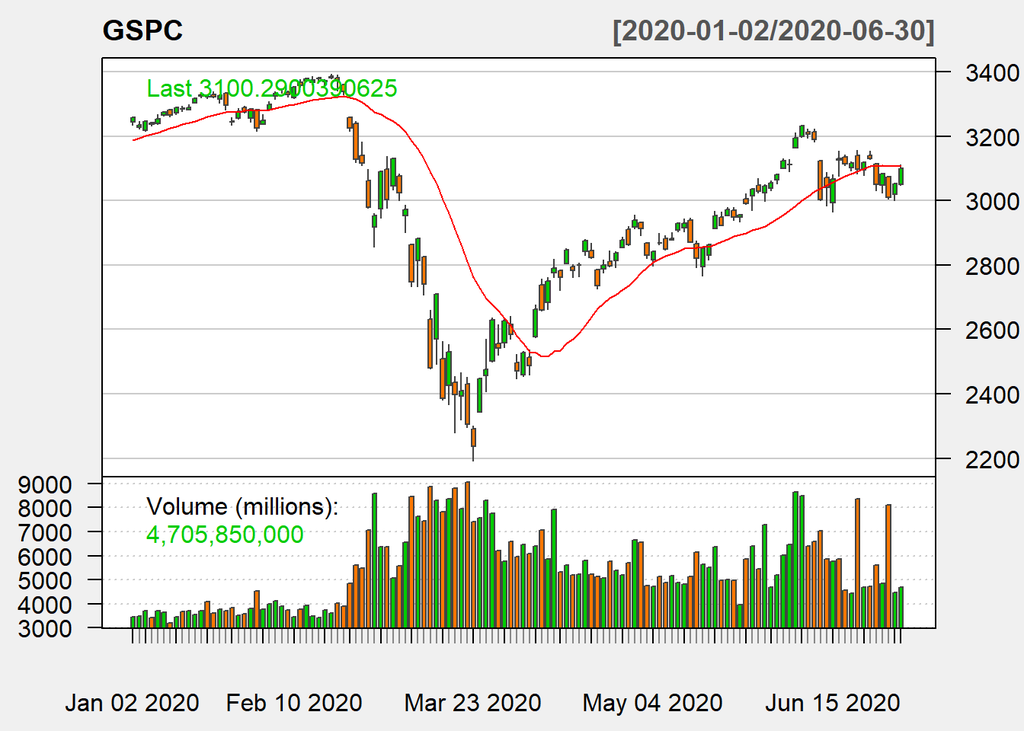

```r
addSMA(n = 20, on = 1, col = 'red')
```

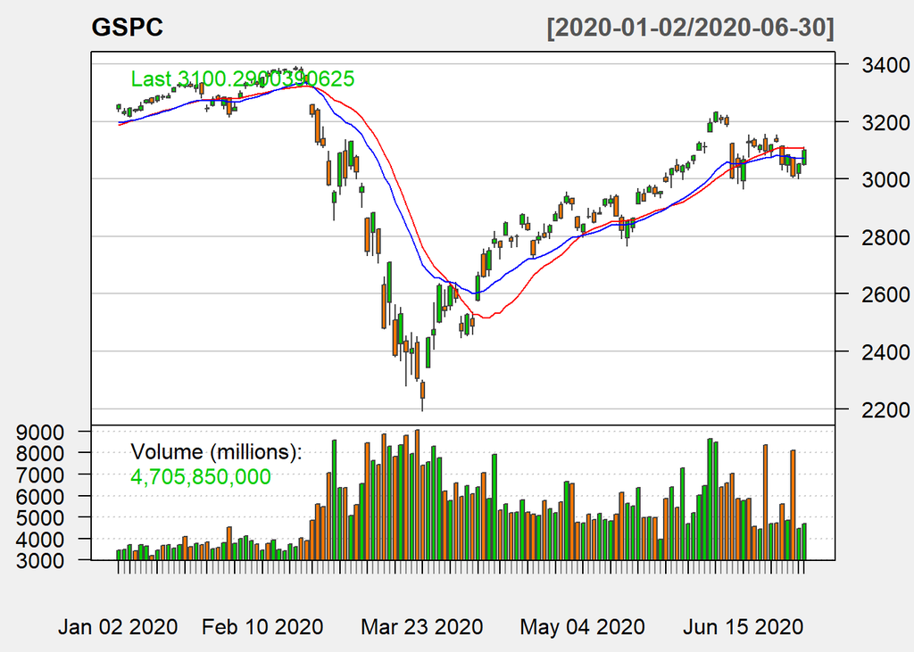

```r
addEMA(n = 20, on = 1, col = 'blue')
```

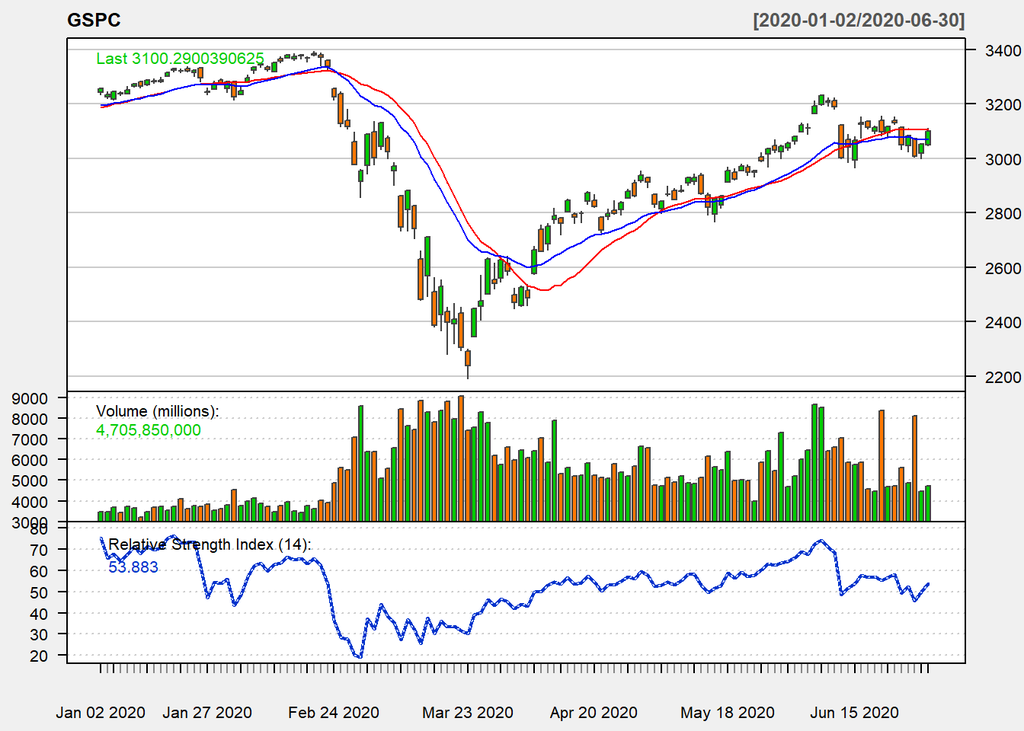

```r
addRSI(n = 14, maType = 'EMA')
```

# 5 Data PreProcessing

```r
data0 <- data.frame(date = index(GSPC), coredata(GSPC))  # convert timeseries to dataframe
head(data0)
```

|  | date | GSPC.Open | GSPC.High | GSPC.Low | GSPC.Close | GSPC.Volume | GSPC.Adjusted |
| --- | --- | --- | --- | --- | --- | --- | --- |
| 1 | 2019-01-02 | 2476.96 | 2519.49 | 2467.47 | 2510.03 | 3733160000 | 2510.03 |
| 2 | 2019-01-03 | 2491.92 | 2493.14 | 2443.96 | 2447.89 | 3858830000 | 2447.89 |
| 3 | 2019-01-04 | 2474.33 | 2538.07 | 2474.33 | 2531.94 | 4234140000 | 2531.94 |
| 4 | 2019-01-07 | 2535.61 | 2566.16 | 2524.56 | 2549.69 | 4133120000 | 2549.69 |
| 5 | 2019-01-08 | 2568.11 | 2579.82 | 2547.56 | 2574.41 | 4120060000 | 2574.41 |
| 6 | 2019-01-09 | 2580.00 | 2595.32 | 2568.89 | 2584.96 | 4088740000 | 2584.96 |

```r
data <- data0[, c('date', 'GSPC.Close', 'GSPC.Volume')]  # our hypothesis about market is: maybe 'trading volume' is an indicator of future market direction
data$rsi <- rsi  # our hypothesis about market is: maybe 'RSI' is a good index which gives us signals about future market direction
colnames(data) <- c('date', 'close_price', 'volume', 'rsi')  # rename columns
head(data)
```

|  | date | close_price | volume | rsi |
| --- | --- | --- | --- | --- |
| 1 | 2019-01-02 | 2510.03 | 3733160000 | NA |
| 2 | 2019-01-03 | 2447.89 | 3858830000 | NA |
| 3 | 2019-01-04 | 2531.94 | 4234140000 | NA |
| 4 | 2019-01-07 | 2549.69 | 4133120000 | NA |
| 5 | 2019-01-08 | 2574.41 | 4120060000 | NA |
| 6 | 2019-01-09 | 2584.96 | 4088740000 | NA |

```r
tail(data)
```

|  | date | close_price | volume | rsi |
| --- | --- | --- | --- | --- |
| 1003 | 2022-12-22 | 3822.39 | 3956950000 | 41.56677 |
| 1004 | 2022-12-23 | 3844.82 | 2819280000 | 43.85289 |
| 1005 | 2022-12-27 | 3829.25 | 3030300000 | 42.60677 |
| 1006 | 2022-12-28 | 3783.22 | 3083520000 | 39.07199 |
| 1007 | 2022-12-29 | 3849.28 | 3003680000 | 45.99649 |
| 1008 | 2022-12-30 | 3839.50 | 2979870000 | 45.17787 |

Calculate daily asset return

```r
data$d_return <- 0
for(i in 2:nrow(data)){  # first day has not any return (because we have not its previous day)
    data$d_return[i] <- data$close_price[i]/data$close_price[i-1] - 1
}
```

Calculate volume change

```r
data$volume_change <- 0
for(i in 2:nrow(data)){
    data$volume_change[i] <- data$volume[i]/data$volume[i-1] - 1
}

head(data)
```

|  | date | close_price | volume | rsi | d_return | volume_change |
| --- | --- | --- | --- | --- | --- | --- |
| 1 | 2019-01-02 | 2510.03 | 3733160000 | NA | 0.000000000 | 0.000000000 |
| 2 | 2019-01-03 | 2447.89 | 3858830000 | NA | -0.024756730 | 0.033663170 |
| 3 | 2019-01-04 | 2531.94 | 4234140000 | NA | 0.034335715 | 0.097260050 |
| 4 | 2019-01-07 | 2549.69 | 4133120000 | NA | 0.007010435 | -0.023858446 |
| 5 | 2019-01-08 | 2574.41 | 4120060000 | NA | 0.009695285 | -0.003159841 |
| 6 | 2019-01-09 | 2584.96 | 4088740000 | NA | 0.004098045 | -0.007601831 |

```r
tail(data)
```

|  | date | close_price | volume | rsi | d_return | volume_change |
| --- | --- | --- | --- | --- | --- | --- |
| 1003 | 2022-12-22 | 3822.39 | 3956950000 | 41.56677 | -0.014451700 | 0.048143145 |
| 1004 | 2022-12-23 | 3844.82 | 2819280000 | 43.85289 | 0.005868103 | -0.287511846 |
| 1005 | 2022-12-27 | 3829.25 | 3030300000 | 42.60677 | -0.004049622 | 0.074848898 |
| 1006 | 2022-12-28 | 3783.22 | 3083520000 | 39.07199 | -0.012020638 | 0.017562618 |
| 1007 | 2022-12-29 | 3849.28 | 3003680000 | 45.99649 | 0.017461332 | -0.025892487 |
| 1008 | 2022-12-30 | 3839.50 | 2979870000 | 45.17787 | -0.002540742 | -0.007926943 |

Plot S&P-500 daily return

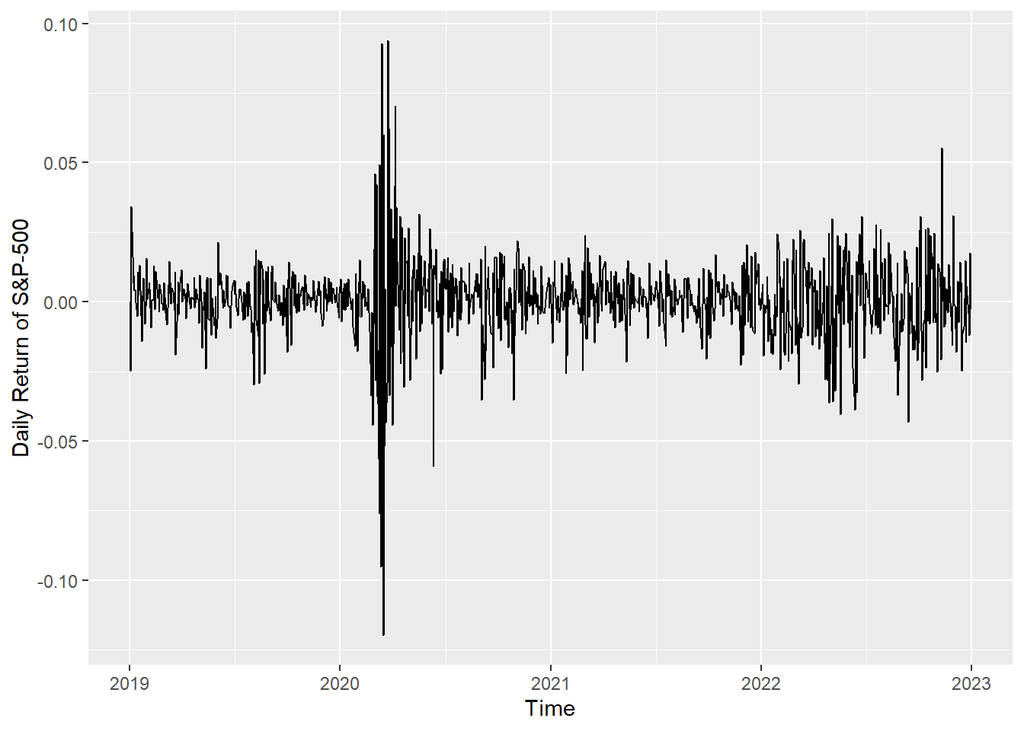

```r
ggplot(data = data, aes(x = date, y = d_return)) +
    geom_line() +
    xlab('Time') +
    scale_y_continuous(name = 'Daily Return of S&P-500')  # it is very noisy and seems that we can not predict it at all!
```

```r
summary(data$d_return)
```

```
##       Min.    1st Qu.     Median       Mean    3rd Qu.       Max.
## -0.1198406 -0.0053271  0.0009416  0.0005264  0.0073891  0.0938277
```

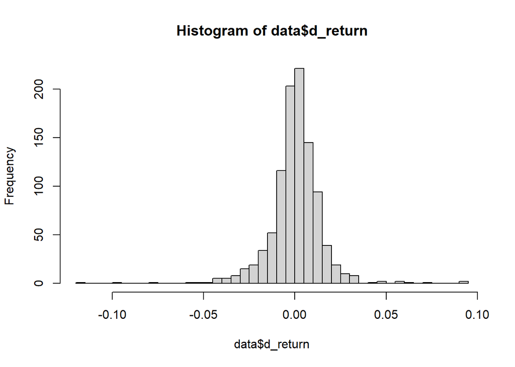

```r
hist(data$d_return, breaks = 50)
```

```r
mean(data$d_return)  # swings around 0
```

```
## [1] 0.0005263801
```

```r
sd(data$d_return)
```

```
## [1] 0.01442906
```

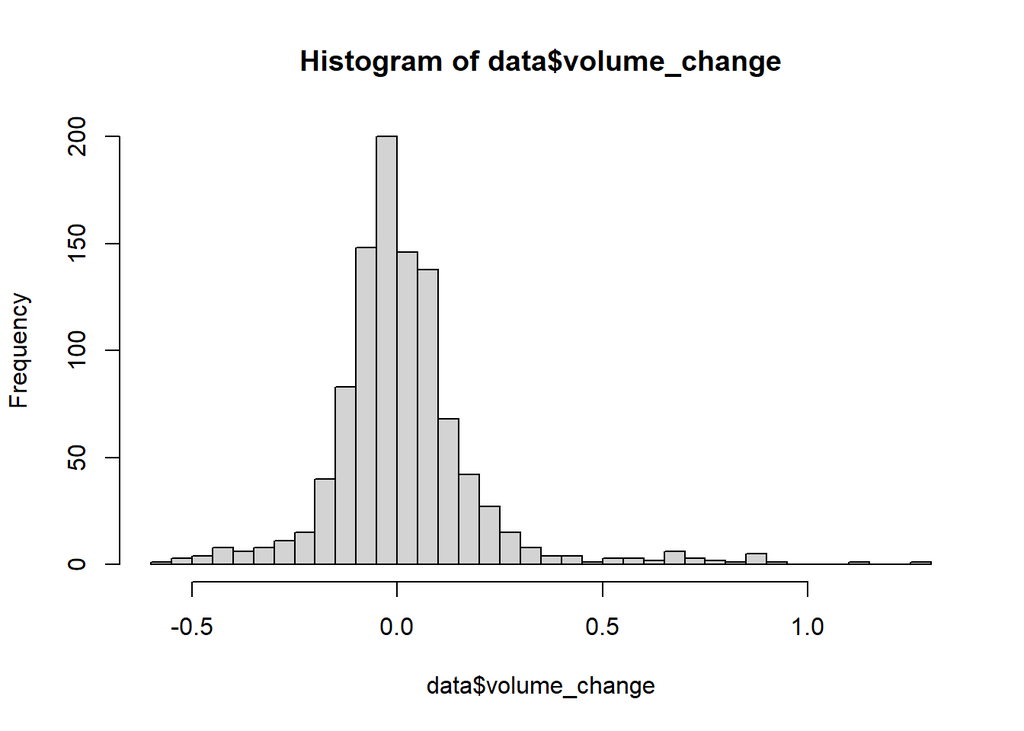

```r
hist(data$volume_change, breaks = 50)  # plot daily volume change
```

```r
data  # we don't access today's information at the beginning of the day (except RSI), we access previous days information
```

| date | close_price | volume | rsi | d_return | volume_change |
| --- | --- | --- | --- | --- | --- |
| 2019-01-02 | 2510.03 | 3733160000 | NA | 0.000000e+00 | 0.000000e+00 |
| 2019-01-03 | 2447.89 | 3858830000 | NA | -2.475673e-02 | 3.366317e-02 |
| 2019-01-04 | 2531.94 | 4234140000 | NA | 3.433571e-02 | 9.726005e-02 |
| 2019-01-07 | 2549.69 | 4133120000 | NA | 7.010435e-03 | -2.385845e-02 |
| 2019-01-08 | 2574.41 | 4120060000 | NA | 9.695285e-03 | -3.159841e-03 |
| 2019-01-09 | 2584.96 | 4088740000 | NA | 4.098045e-03 | -7.601831e-03 |
| 2019-01-10 | 2596.64 | 3721300000 | NA | 4.518419e-03 | -8.986632e-02 |
| 2019-01-11 | 2596.26 | 3447460000 | NA | -1.462978e-04 | -7.358719e-02 |
| 2019-01-14 | 2582.61 | 3689370000 | NA | -5.257525e-03 | 7.017050e-02 |
| 2019-01-15 | 2610.30 | 3601180000 | NA | 1.072169e-02 | -2.390381e-02 |

[output cut: 998 more lines]

> Another hypothesis: maybe if we know daily returns for previous days, they give us a signal about today’s return (direction of market)!

> Another hypothesis: maybe if we know volume changes for previous days, they give us a signal about today’s return (direction of market)!

Add previous lags

daily return lags (for 5 previous days)

```r
data$r_lag1 <- 0
for(i in 2:nrow(data)){
    data$r_lag1[i] <- data$d_return[i-1]
}

data$r_lag2 <- 0
for(i in 3:nrow(data)){
    data$r_lag2[i] <- data$d_return[i-2]
}

data$r_lag3 <- 0
for(i in 4:nrow(data)){
    data$r_lag3[i] <- data$d_return[i-3]
}

data$r_lag4 <- 0
for(i in 5:nrow(data)){
    data$r_lag4[i] <- data$d_return[i-4]
}

data$r_lag5 <- 0
for(i in 6:nrow(data)){
    data$r_lag5[i] <- data$d_return[i-5]
}

head(data)
```

|  | date | close_price | volume | rsi | d_return | volume_change | r_lag1 | r_lag2 | r_lag3 | r_lag4 | r_lag5 |
| --- | --- | --- | --- | --- | --- | --- | --- | --- | --- | --- | --- |
| 1 | 2019-01-02 | 2510.03 | 3733160000 | NA | 0.000000000 | 0.000000000 | 0.000000000 | 0.000000000 | 0.00000000 | 0.00000000 | 0 |
| 2 | 2019-01-03 | 2447.89 | 3858830000 | NA | -0.024756730 | 0.033663170 | 0.000000000 | 0.000000000 | 0.00000000 | 0.00000000 | 0 |
| 3 | 2019-01-04 | 2531.94 | 4234140000 | NA | 0.034335715 | 0.097260050 | -0.024756730 | 0.000000000 | 0.00000000 | 0.00000000 | 0 |
| 4 | 2019-01-07 | 2549.69 | 4133120000 | NA | 0.007010435 | -0.023858446 | 0.034335715 | -0.024756730 | 0.00000000 | 0.00000000 | 0 |
| 5 | 2019-01-08 | 2574.41 | 4120060000 | NA | 0.009695285 | -0.003159841 | 0.007010435 | 0.034335715 | -0.02475673 | 0.00000000 | 0 |
| 6 | 2019-01-09 | 2584.96 | 4088740000 | NA | 0.004098045 | -0.007601831 | 0.009695285 | 0.007010435 | 0.03433571 | -0.02475673 | 0 |

volume change lags (for 5 previous days)

```r
data$v_lag1 <- 0
for(i in 2:nrow(data)){
    data$v_lag1[i] <- data$volume_change[i-1]
}

data$v_lag2 <- 0
for(i in 3:nrow(data)){
    data$v_lag2[i] <- data$volume_change[i-2]
}

data$v_lag3 <- 0
for(i in 4:nrow(data)){
    data$v_lag3[i] <- data$volume_change[i-3]
}

data$v_lag4 <- 0
for(i in 5:nrow(data)){
    data$v_lag4[i] <- data$volume_change[i-4]
}

data$v_lag5 <- 0
for(i in 6:nrow(data)){
    data$v_lag5[i] <- data$volume_change[i-5]
}

head(data)
```

|  | date | close_price | volume | rsi | d_return | volume_change | r_lag1 | r_lag2 | r_lag3 | r_lag4 | r_lag5 | v_lag1 | v_lag2 | v_lag3 | v_lag4 | v_lag5 |
| --- | --- | --- | --- | --- | --- | --- | --- | --- | --- | --- | --- | --- | --- | --- | --- | --- |
| 1 | 2019-01-02 | 2510.03 | 3733160000 | NA | 0.000000000 | 0.000000000 | 0.000000000 | 0.000000000 | 0.00000000 | 0.00000000 | 0 | 0.000000000 | 0.00000000 | 0.00000000 | 0.00000000 | 0 |
| 2 | 2019-01-03 | 2447.89 | 3858830000 | NA | -0.024756730 | 0.033663170 | 0.000000000 | 0.000000000 | 0.00000000 | 0.00000000 | 0 | 0.000000000 | 0.00000000 | 0.00000000 | 0.00000000 | 0 |
| 3 | 2019-01-04 | 2531.94 | 4234140000 | NA | 0.034335715 | 0.097260050 | -0.024756730 | 0.000000000 | 0.00000000 | 0.00000000 | 0 | 0.033663170 | 0.00000000 | 0.00000000 | 0.00000000 | 0 |
| 4 | 2019-01-07 | 2549.69 | 4133120000 | NA | 0.007010435 | -0.023858446 | 0.034335715 | -0.024756730 | 0.00000000 | 0.00000000 | 0 | 0.097260050 | 0.03366317 | 0.00000000 | 0.00000000 | 0 |
| 5 | 2019-01-08 | 2574.41 | 4120060000 | NA | 0.009695285 | -0.003159841 | 0.007010435 | 0.034335715 | -0.02475673 | 0.00000000 | 0 | -0.023858446 | 0.09726005 | 0.03366317 | 0.00000000 | 0 |
| 6 | 2019-01-09 | 2584.96 | 4088740000 | NA | 0.004098045 | -0.007601831 | 0.009695285 | 0.007010435 | 0.03433571 | -0.02475673 | 0 | -0.003159841 | -0.02385845 | 0.09726005 | 0.03366317 | 0 |

add Market Trend (market direction)

```r
data$trend <- ifelse(data$d_return > 0, 1, 0)
data$trend <- factor(data$trend)
head(data)
```

|  | date | close_price | volume | rsi | d_return | volume_change | r_lag1 | r_lag2 | r_lag3 | r_lag4 | r_lag5 | v_lag1 | v_lag2 | v_lag3 | v_lag4 | v_lag5 | trend |
| --- | --- | --- | --- | --- | --- | --- | --- | --- | --- | --- | --- | --- | --- | --- | --- | --- | --- |
| 1 | 2019-01-02 | 2510.03 | 3733160000 | NA | 0.000000000 | 0.000000000 | 0.000000000 | 0.000000000 | 0.00000000 | 0.00000000 | 0 | 0.000000000 | 0.00000000 | 0.00000000 | 0.00000000 | 0 | 0 |
| 2 | 2019-01-03 | 2447.89 | 3858830000 | NA | -0.024756730 | 0.033663170 | 0.000000000 | 0.000000000 | 0.00000000 | 0.00000000 | 0 | 0.000000000 | 0.00000000 | 0.00000000 | 0.00000000 | 0 | 0 |
| 3 | 2019-01-04 | 2531.94 | 4234140000 | NA | 0.034335715 | 0.097260050 | -0.024756730 | 0.000000000 | 0.00000000 | 0.00000000 | 0 | 0.033663170 | 0.00000000 | 0.00000000 | 0.00000000 | 0 | 1 |
| 4 | 2019-01-07 | 2549.69 | 4133120000 | NA | 0.007010435 | -0.023858446 | 0.034335715 | -0.024756730 | 0.00000000 | 0.00000000 | 0 | 0.097260050 | 0.03366317 | 0.00000000 | 0.00000000 | 0 | 1 |
| 5 | 2019-01-08 | 2574.41 | 4120060000 | NA | 0.009695285 | -0.003159841 | 0.007010435 | 0.034335715 | -0.02475673 | 0.00000000 | 0 | -0.023858446 | 0.09726005 | 0.03366317 | 0.00000000 | 0 | 1 |
| 6 | 2019-01-09 | 2584.96 | 4088740000 | NA | 0.004098045 | -0.007601831 | 0.009695285 | 0.007010435 | 0.03433571 | -0.02475673 | 0 | -0.003159841 | -0.02385845 | 0.09726005 | 0.03366317 | 0 | 1 |

Remove first 14 rows (in-complete rows)

```r
data <- data[-c(1:14),]
head(data,15)  # appropriate and complete data for ML model
```

|  | date | close_price | volume | rsi | d_return | volume_change | r_lag1 | r_lag2 | r_lag3 | r_lag4 | r_lag5 | v_lag1 | v_lag2 | v_lag3 | v_lag4 | v_lag5 | trend |
| --- | --- | --- | --- | --- | --- | --- | --- | --- | --- | --- | --- | --- | --- | --- | --- | --- | --- |
| 15 | 2019-01-23 | 2638.70 | 3358770000 | 68.03970 | 0.0022029128 | -0.14403344 | -0.0141573062 | 0.0131830530 | 0.0075914004 | 0.0022219855 | 0.0107216886 | -0.02121721 | 0.05433396 | -0.02054773 | 0.07802998 | -0.02390381 | 1 |
| 16 | 2019-01-24 | 2642.33 | 3449230000 | 68.38625 | 0.0013757256 | 0.02693248 | 0.0022029128 | -0.0141573062 | 0.0131830530 | 0.0075914004 | 0.0022219855 | -0.14403344 | -0.02121721 | 0.05433396 | -0.02054773 | 0.07802998 | 1 |
| 17 | 2019-01-25 | 2664.76 | 3821000000 | 70.51373 | 0.0084886941 | 0.10778348 | 0.0013757256 | 0.0022029128 | -0.0141573062 | 0.0131830530 | 0.0075914004 | 0.02693248 | -0.14403344 | -0.02121721 | 0.05433396 | -0.02054773 | 1 |
| 18 | 2019-01-28 | 2643.85 | 3630820000 | 66.05122 | -0.0078468275 | -0.04977231 | 0.0084886941 | 0.0013757256 | 0.0022029128 | -0.0141573062 | 0.0131830530 | 0.10778348 | 0.02693248 | -0.14403344 | -0.02121721 | 0.05433396 | 0 |
| 19 | 2019-01-29 | 2640.00 | 3518070000 | 65.23262 | -0.0014562466 | -0.03105359 | -0.0078468275 | 0.0084886941 | 0.0013757256 | 0.0022029128 | -0.0141573062 | -0.04977231 | 0.10778348 | 0.02693248 | -0.14403344 | -0.02121721 | 0 |
| 20 | 2019-01-30 | 2681.05 | 3883270000 | 69.56383 | 0.0155492609 | 0.10380692 | -0.0014562466 | -0.0078468275 | 0.0084886941 | 0.0013757256 | 0.0022029128 | -0.03105359 | -0.04977231 | 0.10778348 | 0.02693248 | -0.14403344 | 1 |
| 21 | 2019-01-31 | 2704.10 | 4953800000 | 71.69603 | 0.0085973959 | 0.27567746 | 0.0155492609 | -0.0014562466 | -0.0078468275 | 0.0084886941 | 0.0013757256 | 0.10380692 | -0.03105359 | -0.04977231 | 0.10778348 | 0.02693248 | 1 |
| 22 | 2019-02-01 | 2706.53 | 3782490000 | 71.91936 | 0.0008986101 | -0.23644677 | 0.0085973959 | 0.0155492609 | -0.0014562466 | -0.0078468275 | 0.0084886941 | 0.27567746 | 0.10380692 | -0.03105359 | -0.04977231 | 0.10778348 | 1 |
| 23 | 2019-02-04 | 2724.87 | 3369450000 | 73.61178 | 0.0067762366 | -0.10919791 | 0.0008986101 | 0.0085973959 | 0.0155492609 | -0.0014562466 | -0.0078468275 | -0.23644677 | 0.27567746 | 0.10380692 | -0.03105359 | -0.04977231 | 1 |
| 24 | 2019-02-05 | 2737.70 | 3597620000 | 74.75790 | 0.0047084204 | 0.06771728 | 0.0067762366 | 0.0008986101 | 0.0085973959 | 0.0155492609 | -0.0014562466 | -0.10919791 | -0.23644677 | 0.27567746 | 0.10380692 | -0.03105359 | 1 |

[output cut: 5 more lines]

## 5.1 Divide Dataset into Train and Test

```r
train <- data[format(data$date, '%Y') %in% c('2019', '2020'),]  # for train models
head(train)
```

|  | date | close_price | volume | rsi | d_return | volume_change | r_lag1 | r_lag2 | r_lag3 | r_lag4 | r_lag5 | v_lag1 | v_lag2 | v_lag3 | v_lag4 | v_lag5 | trend |
| --- | --- | --- | --- | --- | --- | --- | --- | --- | --- | --- | --- | --- | --- | --- | --- | --- | --- |
| 15 | 2019-01-23 | 2638.70 | 3358770000 | 68.03970 | 0.002202913 | -0.14403344 | -0.014157306 | 0.013183053 | 0.007591400 | 0.002221985 | 0.010721689 | -0.02121721 | 0.05433396 | -0.02054773 | 0.07802998 | -0.02390381 | 1 |
| 16 | 2019-01-24 | 2642.33 | 3449230000 | 68.38625 | 0.001375726 | 0.02693248 | 0.002202913 | -0.014157306 | 0.013183053 | 0.007591400 | 0.002221985 | -0.14403344 | -0.02121721 | 0.05433396 | -0.02054773 | 0.07802998 | 1 |
| 17 | 2019-01-25 | 2664.76 | 3821000000 | 70.51373 | 0.008488694 | 0.10778348 | 0.001375726 | 0.002202913 | -0.014157306 | 0.013183053 | 0.007591400 | 0.02693248 | -0.14403344 | -0.02121721 | 0.05433396 | -0.02054773 | 1 |
| 18 | 2019-01-28 | 2643.85 | 3630820000 | 66.05122 | -0.007846827 | -0.04977231 | 0.008488694 | 0.001375726 | 0.002202913 | -0.014157306 | 0.013183053 | 0.10778348 | 0.02693248 | -0.14403344 | -0.02121721 | 0.05433396 | 0 |
| 19 | 2019-01-29 | 2640.00 | 3518070000 | 65.23262 | -0.001456247 | -0.03105359 | -0.007846827 | 0.008488694 | 0.001375726 | 0.002202913 | -0.014157306 | -0.04977231 | 0.10778348 | 0.02693248 | -0.14403344 | -0.02121721 | 0 |
| 20 | 2019-01-30 | 2681.05 | 3883270000 | 69.56383 | 0.015549261 | 0.10380692 | -0.001456247 | -0.007846827 | 0.008488694 | 0.001375726 | 0.002202913 | -0.03105359 | -0.04977231 | 0.10778348 | 0.02693248 | -0.14403344 | 1 |

```r
tail(train)
```

|  | date | close_price | volume | rsi | d_return | volume_change | r_lag1 | r_lag2 | r_lag3 | r_lag4 | r_lag5 | v_lag1 | v_lag2 | v_lag3 | v_lag4 | v_lag5 | trend |
| --- | --- | --- | --- | --- | --- | --- | --- | --- | --- | --- | --- | --- | --- | --- | --- | --- | --- |
| 500 | 2020-12-23 | 3690.01 | 3779160000 | 59.23968 | 0.0007458113 | -0.067636080 | -0.0020730929 | -0.0039062791 | -0.0035111185 | 0.0057576548 | 0.0017727952 | -0.14641640 | -0.33091263 | 0.69268343 | 0.03092421 | -0.07295057 | 1 |
| 501 | 2020-12-24 | 3703.06 | 1883780000 | 61.27866 | 0.0035365890 | -0.501534733 | 0.0007458113 | -0.0020730929 | -0.0039062791 | -0.0035111185 | 0.0057576548 | -0.06763608 | -0.14641640 | -0.33091263 | 0.69268343 | 0.03092421 | 1 |
| 502 | 2020-12-28 | 3735.36 | 3535460000 | 65.83422 | 0.0087225290 | 0.876790283 | 0.0035365890 | 0.0007458113 | -0.0020730929 | -0.0039062791 | -0.0035111185 | -0.50153473 | -0.06763608 | -0.14641640 | -0.33091263 | 0.69268343 | 1 |
| 503 | 2020-12-29 | 3727.04 | 3393290000 | 63.75355 | -0.0022273805 | -0.040212589 | 0.0087225290 | 0.0035365890 | 0.0007458113 | -0.0020730929 | -0.0039062791 | 0.87679028 | -0.50153473 | -0.06763608 | -0.14641640 | -0.33091263 | 0 |
| 504 | 2020-12-30 | 3732.04 | 3154850000 | 64.48008 | 0.0013415472 | -0.070268088 | -0.0022273805 | 0.0087225290 | 0.0035365890 | 0.0007458113 | -0.0020730929 | -0.04021259 | 0.87679028 | -0.50153473 | -0.06763608 | -0.14641640 | 1 |
| 505 | 2020-12-31 | 3756.07 | 3179040000 | 67.81865 | 0.0064388455 | 0.007667559 | 0.0013415472 | -0.0022273805 | 0.0087225290 | 0.0035365890 | 0.0007458113 | -0.07026809 | -0.04021259 | 0.87679028 | -0.50153473 | -0.06763608 | 1 |

```r
test <- data[format(data$date, '%Y') == '2021',]  # for test models
head(test)
```

|  | date | close_price | volume | rsi | d_return | volume_change | r_lag1 | r_lag2 | r_lag3 | r_lag4 | r_lag5 | v_lag1 | v_lag2 | v_lag3 | v_lag4 | v_lag5 | trend |
| --- | --- | --- | --- | --- | --- | --- | --- | --- | --- | --- | --- | --- | --- | --- | --- | --- | --- |
| 506 | 2021-01-04 | 3700.65 | 5015000000 | 54.98307 | -0.014754828 | 0.57752026 | 0.006438846 | 0.001341547 | -0.002227381 | 0.008722529 | 0.003536589 | 0.007667559 | -0.070268088 | -0.040212589 | 0.876790283 | -0.501534733 | 0 |
| 507 | 2021-01-05 | 3726.86 | 4591020000 | 58.94095 | 0.007082595 | -0.08454237 | -0.014754828 | 0.006438846 | 0.001341547 | -0.002227381 | 0.008722529 | 0.577520258 | 0.007667559 | -0.070268088 | -0.040212589 | 0.876790283 | 1 |
| 508 | 2021-01-06 | 3748.14 | 6064110000 | 61.87193 | 0.005709843 | 0.32086334 | 0.007082595 | -0.014754828 | 0.006438846 | 0.001341547 | -0.002227381 | -0.084542373 | 0.577520258 | 0.007667559 | -0.070268088 | -0.040212589 | 1 |
| 509 | 2021-01-07 | 3803.79 | 5099160000 | 68.25418 | 0.014847404 | -0.15912475 | 0.005709843 | 0.007082595 | -0.014754828 | 0.006438846 | 0.001341547 | 0.320863338 | -0.084542373 | 0.577520258 | 0.007667559 | -0.070268088 | 1 |
| 510 | 2021-01-08 | 3824.68 | 4773040000 | 70.26621 | 0.005491863 | -0.06395563 | 0.014847404 | 0.005709843 | 0.007082595 | -0.014754828 | 0.006438846 | -0.159124752 | 0.320863338 | -0.084542373 | 0.577520258 | 0.007667559 | 1 |
| 511 | 2021-01-11 | 3799.61 | 4465430000 | 64.94633 | -0.006554751 | -0.06444740 | 0.005491863 | 0.014847404 | 0.005709843 | 0.007082595 | -0.014754828 | -0.063955632 | -0.159124752 | 0.320863338 | -0.084542373 | 0.577520258 | 0 |

```r
tail(test)
```

|  | date | close_price | volume | rsi | d_return | volume_change | r_lag1 | r_lag2 | r_lag3 | r_lag4 | r_lag5 | v_lag1 | v_lag2 | v_lag3 | v_lag4 | v_lag5 | trend |
| --- | --- | --- | --- | --- | --- | --- | --- | --- | --- | --- | --- | --- | --- | --- | --- | --- | --- |
| 752 | 2021-12-23 | 4725.79 | 2913040000 | 56.96881 | 0.006223700 | -0.12247523 | 0.010180197 | 0.017777935 | -0.011388058 | -0.01028768 | -0.008743415 | -0.18485769 | -0.12150700 | -0.41960088 | 0.65381302 | -0.01642115 | 1 |
| 753 | 2021-12-27 | 4791.19 | 2770290000 | 61.35847 | 0.013838935 | -0.04900379 | 0.006223700 | 0.010180197 | 0.017777935 | -0.01138806 | -0.010287681 | -0.12247523 | -0.18485769 | -0.12150700 | -0.41960088 | 0.65381302 | 1 |
| 754 | 2021-12-28 | 4786.35 | 2707920000 | 60.86366 | -0.001010155 | -0.02251389 | 0.013838935 | 0.006223700 | 0.010180197 | 0.01777793 | -0.011388058 | -0.04900379 | -0.12247523 | -0.18485769 | -0.12150700 | -0.41960088 | 0 |
| 755 | 2021-12-29 | 4793.06 | 2963310000 | 61.32927 | 0.001401895 | 0.09431224 | -0.001010155 | 0.013838935 | 0.006223700 | 0.01018020 | 0.017777935 | -0.02251389 | -0.04900379 | -0.12247523 | -0.18485769 | -0.12150700 | 1 |
| 756 | 2021-12-30 | 4778.73 | 3124950000 | 59.69583 | -0.002989756 | 0.05454711 | 0.001401895 | -0.001010155 | 0.013838935 | 0.00622370 | 0.010180197 | 0.09431224 | -0.02251389 | -0.04900379 | -0.12247523 | -0.18485769 | 0 |
| 757 | 2021-12-31 | 4766.18 | 2677820000 | 58.23305 | -0.002626180 | -0.14308389 | -0.002989756 | 0.001401895 | -0.001010155 | 0.01383894 | 0.006223700 | 0.05454711 | 0.09431224 | -0.02251389 | -0.04900379 | -0.12247523 | 0 |

```r
real <- data[format(data$date, '%Y') == '2022',]  # for trade in real with models (simulate trading)
head(real)
```

|  | date | close_price | volume | rsi | d_return | volume_change | r_lag1 | r_lag2 | r_lag3 | r_lag4 | r_lag5 | v_lag1 | v_lag2 | v_lag3 | v_lag4 | v_lag5 | trend |
| --- | --- | --- | --- | --- | --- | --- | --- | --- | --- | --- | --- | --- | --- | --- | --- | --- | --- |
| 758 | 2022-01-03 | 4796.56 | 3831020000 | 60.74094 | 0.006374053 | 0.43064881 | -0.002626180 | -0.002989756 | 0.001401895 | -0.001010155 | 0.013838935 | -0.14308389 | 0.05454711 | 0.09431224 | -0.02251389 | -0.04900379 | 1 |
| 759 | 2022-01-04 | 4793.54 | 4683170000 | 60.35298 | -0.000629622 | 0.22243423 | 0.006374053 | -0.002626180 | -0.002989756 | 0.001401895 | -0.001010155 | 0.43064881 | -0.14308389 | 0.05454711 | 0.09431224 | -0.02251389 | 0 |
| 760 | 2022-01-05 | 4700.58 | 4887960000 | 49.80751 | -0.019392758 | 0.04372893 | -0.000629622 | 0.006374053 | -0.002626180 | -0.002989756 | 0.001401895 | 0.22243423 | 0.43064881 | -0.14308389 | 0.05454711 | 0.09431224 | 0 |
| 761 | 2022-01-06 | 4696.05 | 4295280000 | 49.35491 | -0.000963769 | -0.12125304 | -0.019392758 | -0.000629622 | 0.006374053 | -0.002626180 | -0.002989756 | 0.04372893 | 0.22243423 | 0.43064881 | -0.14308389 | 0.05454711 | 0 |
| 762 | 2022-01-07 | 4677.03 | 4181510000 | 47.40717 | -0.004050217 | -0.02648721 | -0.000963769 | -0.019392758 | -0.000629622 | 0.006374053 | -0.002626180 | -0.12125304 | 0.04372893 | 0.22243423 | 0.43064881 | -0.14308389 | 0 |
| 763 | 2022-01-10 | 4670.29 | 4511810000 | 46.70382 | -0.001441031 | 0.07899060 | -0.004050217 | -0.000963769 | -0.019392758 | -0.000629622 | 0.006374053 | -0.02648721 | -0.12125304 | 0.04372893 | 0.22243423 | 0.43064881 | 0 |

```r
tail(real)
```

|  | date | close_price | volume | rsi | d_return | volume_change | r_lag1 | r_lag2 | r_lag3 | r_lag4 | r_lag5 | v_lag1 | v_lag2 | v_lag3 | v_lag4 | v_lag5 | trend |
| --- | --- | --- | --- | --- | --- | --- | --- | --- | --- | --- | --- | --- | --- | --- | --- | --- | --- |
| 1003 | 2022-12-22 | 3822.39 | 3956950000 | 41.56677 | -0.014451700 | 0.048143145 | 0.014867994 | 0.001037338 | -0.009007516 | -0.011137751 | -0.024921675 | -0.05273538 | 0.003970163 | -0.470270869 | 0.667518191 | 0.004820743 | 0 |
| 1004 | 2022-12-23 | 3844.82 | 2819280000 | 43.85289 | 0.005868103 | -0.287511846 | -0.014451700 | 0.014867994 | 0.001037338 | -0.009007516 | -0.011137751 | 0.04814314 | -0.052735380 | 0.003970163 | -0.470270869 | 0.667518191 | 1 |
| 1005 | 2022-12-27 | 3829.25 | 3030300000 | 42.60677 | -0.004049622 | 0.074848898 | 0.005868103 | -0.014451700 | 0.014867994 | 0.001037338 | -0.009007516 | -0.28751185 | 0.048143145 | -0.052735380 | 0.003970163 | -0.470270869 | 0 |
| 1006 | 2022-12-28 | 3783.22 | 3083520000 | 39.07199 | -0.012020638 | 0.017562618 | -0.004049622 | 0.005868103 | -0.014451700 | 0.014867994 | 0.001037338 | 0.07484890 | -0.287511846 | 0.048143145 | -0.052735380 | 0.003970163 | 0 |
| 1007 | 2022-12-29 | 3849.28 | 3003680000 | 45.99649 | 0.017461332 | -0.025892487 | -0.012020638 | -0.004049622 | 0.005868103 | -0.014451700 | 0.014867994 | 0.01756262 | 0.074848898 | -0.287511846 | 0.048143145 | -0.052735380 | 1 |
| 1008 | 2022-12-30 | 3839.50 | 2979870000 | 45.17787 | -0.002540742 | -0.007926943 | 0.017461332 | -0.012020638 | -0.004049622 | 0.005868103 | -0.014451700 | -0.02589249 | 0.017562618 | 0.074848898 | -0.287511846 | 0.048143145 | 0 |

# 6 Descriptive Analysis

## 6.1 Correlation Analysis

We can’t calculate “pearson” correlation on trend (Binary-Categorical variable), but trend == d_return

```r
cor_table1 <- round(cor(data[, c(5, 7:11, 4)]) , 2)  # pearson correlation between d_return & rsi & d_return lags
cor_table1  # rsi and r_lag1 have good linear relationship with d_return
```

```
##          d_return r_lag1 r_lag2 r_lag3 r_lag4 r_lag5  rsi
## d_return     1.00  -0.21   0.14  -0.03  -0.07   0.08 0.29
## r_lag1      -0.21   1.00  -0.21   0.14  -0.03  -0.07 0.24
## r_lag2       0.14  -0.21   1.00  -0.21   0.14  -0.03 0.24
## r_lag3      -0.03   0.14  -0.21   1.00  -0.21   0.14 0.21
## r_lag4      -0.07  -0.03   0.14  -0.21   1.00  -0.21 0.18
## r_lag5       0.08  -0.07  -0.03   0.14  -0.21   1.00 0.18
## rsi          0.29   0.24   0.24   0.21   0.18   0.18 1.00
```

```r
cor_table2 <- round(cor(data[, c(5, 12:16)]), 2)  # pearson correlation between d_return & v_change lags
cor_table2
```

```
##          d_return v_lag1 v_lag2 v_lag3 v_lag4 v_lag5
## d_return     1.00   0.00   0.04  -0.05   0.02  -0.02
## v_lag1       0.00   1.00  -0.35  -0.03  -0.04  -0.01
## v_lag2       0.04  -0.35   1.00  -0.35  -0.03  -0.04
## v_lag3      -0.05  -0.03  -0.35   1.00  -0.35  -0.03
## v_lag4       0.02  -0.04  -0.03  -0.35   1.00  -0.35
## v_lag5      -0.02  -0.01  -0.04  -0.03  -0.35   1.00
```

# 7 Modeling

## 7.1 Model 1: Logistic Regression

```r
model_rm1 <- glm(trend ~ rsi +
            r_lag1 + r_lag2 + r_lag3 + r_lag4 + r_lag5 +
            v_lag1 + v_lag2 + v_lag3 + v_lag4 + v_lag5,
            family = 'binomial',
            data = train)
summary(model_rm1)
```

```
##
## Call:
## glm(formula = trend ~ rsi + r_lag1 + r_lag2 + r_lag3 + r_lag4 +
##     r_lag5 + v_lag1 + v_lag2 + v_lag3 + v_lag4 + v_lag5, family = "binomial",
##     data = train)
##
## Coefficients:
##               Estimate Std. Error z value Pr(>|z|)
## (Intercept)  -4.583253   0.661652  -6.927 4.30e-12 ***
## rsi           0.087225   0.011526   7.568 3.79e-14 ***
## r_lag1      -39.882583   8.856120  -4.503 6.69e-06 ***
## r_lag2      -14.074650   7.938933  -1.773   0.0763 .
## r_lag3      -26.623298   8.875962  -2.999   0.0027 **
## r_lag4      -20.301203   8.081729  -2.512   0.0120 *
## r_lag5      -13.445849   7.841768  -1.715   0.0864 .
## v_lag1       -0.590316   0.590380  -1.000   0.3174
## v_lag2       -0.009703   0.667314  -0.015   0.9884
## v_lag3       -0.742554   0.687324  -1.080   0.2800
## v_lag4       -0.571622   0.679190  -0.842   0.4000
## v_lag5       -0.898413   0.599469  -1.499   0.1340
## ---
## Signif. codes:  0 '***' 0.001 '**' 0.01 '*' 0.05 '.' 0.1 ' ' 1
##
## (Dispersion parameter for binomial family taken to be 1)
##
##     Null deviance: 667.90  on 490  degrees of freedom
## Residual deviance: 582.73  on 479  degrees of freedom
## AIC: 606.73
##
## Number of Fisher Scoring iterations: 4
```

> Consider coefficients based on Wald-test results: choose significant variables to be present on next model

```r
model_rm2 <- glm(trend ~ rsi +
            r_lag1 + r_lag2 + r_lag3 + r_lag4 + r_lag5,
            family = 'binomial',
            data = train)
summary(model_rm2)
```

```
##
## Call:
## glm(formula = trend ~ rsi + r_lag1 + r_lag2 + r_lag3 + r_lag4 +
##     r_lag5, family = "binomial", data = train)
##
## Coefficients:
##              Estimate Std. Error z value Pr(>|z|)
## (Intercept)  -4.56831    0.65935  -6.929 4.25e-12 ***
## rsi           0.08606    0.01144   7.520 5.48e-14 ***
## r_lag1      -38.68325    8.73716  -4.427 9.54e-06 ***
## r_lag2      -13.57676    7.88262  -1.722  0.08500 .
## r_lag3      -25.09713    8.68984  -2.888  0.00388 **
## r_lag4      -19.88399    7.98586  -2.490  0.01278 *
## r_lag5      -11.59746    7.66011  -1.514  0.13002
## ---
## Signif. codes:  0 '***' 0.001 '**' 0.01 '*' 0.05 '.' 0.1 ' ' 1
##
## (Dispersion parameter for binomial family taken to be 1)
##
##     Null deviance: 667.90  on 490  degrees of freedom
## Residual deviance: 586.72  on 484  degrees of freedom
## AIC: 600.72
##
## Number of Fisher Scoring iterations: 4
```

> **r_lag2** is partially Significant, so we keep it in the model

### 7.1.1 Prediction on train

```r
train$probs <- predict(model_rm2, train, type = 'response')  # output of Logistic Regression is p(Y=1)
head(train)
```

|  | date | close_price | volume | rsi | d_return | volume_change | r_lag1 | r_lag2 | r_lag3 | r_lag4 | r_lag5 | v_lag1 | v_lag2 | v_lag3 | v_lag4 | v_lag5 | trend | probs |
| --- | --- | --- | --- | --- | --- | --- | --- | --- | --- | --- | --- | --- | --- | --- | --- | --- | --- | --- |
| 15 | 2019-01-23 | 2638.70 | 3358770000 | 68.03970 | 0.002202913 | -0.14403344 | -0.014157306 | 0.013183053 | 0.007591400 | 0.002221985 | 0.010721689 | -0.02121721 | 0.05433396 | -0.02054773 | 0.07802998 | -0.02390381 | 1 | 0.7852976 |
| 16 | 2019-01-24 | 2642.33 | 3449230000 | 68.38625 | 0.001375726 | 0.02693248 | 0.002202913 | -0.014157306 | 0.013183053 | 0.007591400 | 0.002221985 | -0.14403344 | -0.02121721 | 0.05433396 | -0.02054773 | 0.07802998 | 1 | 0.7143153 |
| 17 | 2019-01-25 | 2664.76 | 3821000000 | 70.51373 | 0.008488694 | 0.10778348 | 0.001375726 | 0.002202913 | -0.014157306 | 0.013183053 | 0.007591400 | 0.02693248 | -0.14403344 | -0.02121721 | 0.05433396 | -0.02054773 | 1 | 0.8056697 |
| 18 | 2019-01-28 | 2643.85 | 3630820000 | 66.05122 | -0.007846827 | -0.04977231 | 0.008488694 | 0.001375726 | 0.002202913 | -0.014157306 | 0.013183053 | 0.10778348 | 0.02693248 | -0.14403344 | -0.02121721 | 0.05433396 | 0 | 0.6989580 |
| 19 | 2019-01-29 | 2640.00 | 3518070000 | 65.23262 | -0.001456247 | -0.03105359 | -0.007846827 | 0.008488694 | 0.001375726 | 0.002202913 | -0.014157306 | -0.04977231 | 0.10778348 | 0.02693248 | -0.14403344 | -0.02121721 | 0 | 0.7891424 |
| 20 | 2019-01-30 | 2681.05 | 3883270000 | 69.56383 | 0.015549261 | 0.10380692 | -0.001456247 | -0.007846827 | 0.008488694 | 0.001375726 | 0.002202913 | -0.03105359 | -0.04977231 | 0.10778348 | 0.02693248 | -0.14403344 | 1 | 0.7883953 |

```r
train$pred_logreg <- ifelse(train$probs >= 0.42, 1, 0)  # Threshold is 0.42
head(train)
```

|  | date | close_price | volume | rsi | d_return | volume_change | r_lag1 | r_lag2 | r_lag3 | r_lag4 | r_lag5 | v_lag1 | v_lag2 | v_lag3 | v_lag4 | v_lag5 | trend | probs | pred_logreg |
| --- | --- | --- | --- | --- | --- | --- | --- | --- | --- | --- | --- | --- | --- | --- | --- | --- | --- | --- | --- |
| 15 | 2019-01-23 | 2638.70 | 3358770000 | 68.03970 | 0.002202913 | -0.14403344 | -0.014157306 | 0.013183053 | 0.007591400 | 0.002221985 | 0.010721689 | -0.02121721 | 0.05433396 | -0.02054773 | 0.07802998 | -0.02390381 | 1 | 0.7852976 | 1 |
| 16 | 2019-01-24 | 2642.33 | 3449230000 | 68.38625 | 0.001375726 | 0.02693248 | 0.002202913 | -0.014157306 | 0.013183053 | 0.007591400 | 0.002221985 | -0.14403344 | -0.02121721 | 0.05433396 | -0.02054773 | 0.07802998 | 1 | 0.7143153 | 1 |
| 17 | 2019-01-25 | 2664.76 | 3821000000 | 70.51373 | 0.008488694 | 0.10778348 | 0.001375726 | 0.002202913 | -0.014157306 | 0.013183053 | 0.007591400 | 0.02693248 | -0.14403344 | -0.02121721 | 0.05433396 | -0.02054773 | 1 | 0.8056697 | 1 |
| 18 | 2019-01-28 | 2643.85 | 3630820000 | 66.05122 | -0.007846827 | -0.04977231 | 0.008488694 | 0.001375726 | 0.002202913 | -0.014157306 | 0.013183053 | 0.10778348 | 0.02693248 | -0.14403344 | -0.02121721 | 0.05433396 | 0 | 0.6989580 | 1 |
| 19 | 2019-01-29 | 2640.00 | 3518070000 | 65.23262 | -0.001456247 | -0.03105359 | -0.007846827 | 0.008488694 | 0.001375726 | 0.002202913 | -0.014157306 | -0.04977231 | 0.10778348 | 0.02693248 | -0.14403344 | -0.02121721 | 0 | 0.7891424 | 1 |
| 20 | 2019-01-30 | 2681.05 | 3883270000 | 69.56383 | 0.015549261 | 0.10380692 | -0.001456247 | -0.007846827 | 0.008488694 | 0.001375726 | 0.002202913 | -0.03105359 | -0.04977231 | 0.10778348 | 0.02693248 | -0.14403344 | 1 | 0.7883953 | 1 |

```r
mean(train$pred_logreg == train$trend) * 100
```

```
## [1] 68.63544
```

> Model preformance on Train dataset is 68.63% (in 68% of days in years 2019-2020 we had true prediction of market direction)

Confusion matrix

```r
table(actual = train$trend, prediction = train$pred_logreg)
```

```
##       prediction
## actual   0   1
##      0  80 126
##      1  28 257
```

```r
sum(train$trend == 1)  # 285 days market was ascending
```

```
## [1] 285
```

```r
sum(train$trend == 0)  # 206 days market was descending
```

```
## [1] 206
```

### 7.1.2 Prediction on test

```r
test$probs <- predict(model_rm2, test, type = 'response')
head(test)
```

|  | date | close_price | volume | rsi | d_return | volume_change | r_lag1 | r_lag2 | r_lag3 | r_lag4 | r_lag5 | v_lag1 | v_lag2 | v_lag3 | v_lag4 | v_lag5 | trend | probs |
| --- | --- | --- | --- | --- | --- | --- | --- | --- | --- | --- | --- | --- | --- | --- | --- | --- | --- | --- |
| 506 | 2021-01-04 | 3700.65 | 5015000000 | 54.98307 | -0.014754828 | 0.57752026 | 0.006438846 | 0.001341547 | -0.002227381 | 0.008722529 | 0.003536589 | 0.007667559 | -0.070268088 | -0.040212589 | 0.876790283 | -0.501534733 | 0 | 0.4347965 |
| 507 | 2021-01-05 | 3726.86 | 4591020000 | 58.94095 | 0.007082595 | -0.08454237 | -0.014754828 | 0.006438846 | 0.001341547 | -0.002227381 | 0.008722529 | 0.577520258 | 0.007667559 | -0.070268088 | -0.040212589 | 0.876790283 | 1 | 0.7103239 |
| 508 | 2021-01-06 | 3748.14 | 6064110000 | 61.87193 | 0.005709843 | 0.32086334 | 0.007082595 | -0.014754828 | 0.006438846 | 0.001341547 | -0.002227381 | -0.084542373 | 0.577520258 | 0.007667559 | -0.070268088 | -0.040212589 | 1 | 0.6272171 |
| 509 | 2021-01-07 | 3803.79 | 5099160000 | 68.25418 | 0.014847404 | -0.15912475 | 0.005709843 | 0.007082595 | -0.014754828 | 0.006438846 | 0.001341547 | 0.320863338 | -0.084542373 | 0.577520258 | 0.007667559 | -0.070268088 | 1 | 0.7712408 |
| 510 | 2021-01-08 | 3824.68 | 4773040000 | 70.26621 | 0.005491863 | -0.06395563 | 0.014847404 | 0.005709843 | 0.007082595 | -0.014754828 | 0.006438846 | -0.159124752 | 0.320863338 | -0.084542373 | 0.577520258 | 0.007667559 | 1 | 0.7043076 |
| 511 | 2021-01-11 | 3799.61 | 4465430000 | 64.94633 | -0.006554751 | -0.06444740 | 0.005491863 | 0.014847404 | 0.005709843 | 0.007082595 | -0.014754828 | -0.063955632 | -0.159124752 | 0.320863338 | -0.084542373 | 0.577520258 | 0 | 0.6210341 |

```r
test$pred_logreg <- ifelse(test$probs >= 0.5, 1, 0)  # Threshold is 0.5
head(train)
```

|  | date | close_price | volume | rsi | d_return | volume_change | r_lag1 | r_lag2 | r_lag3 | r_lag4 | r_lag5 | v_lag1 | v_lag2 | v_lag3 | v_lag4 | v_lag5 | trend | probs | pred_logreg |
| --- | --- | --- | --- | --- | --- | --- | --- | --- | --- | --- | --- | --- | --- | --- | --- | --- | --- | --- | --- |
| 15 | 2019-01-23 | 2638.70 | 3358770000 | 68.03970 | 0.002202913 | -0.14403344 | -0.014157306 | 0.013183053 | 0.007591400 | 0.002221985 | 0.010721689 | -0.02121721 | 0.05433396 | -0.02054773 | 0.07802998 | -0.02390381 | 1 | 0.7852976 | 1 |
| 16 | 2019-01-24 | 2642.33 | 3449230000 | 68.38625 | 0.001375726 | 0.02693248 | 0.002202913 | -0.014157306 | 0.013183053 | 0.007591400 | 0.002221985 | -0.14403344 | -0.02121721 | 0.05433396 | -0.02054773 | 0.07802998 | 1 | 0.7143153 | 1 |
| 17 | 2019-01-25 | 2664.76 | 3821000000 | 70.51373 | 0.008488694 | 0.10778348 | 0.001375726 | 0.002202913 | -0.014157306 | 0.013183053 | 0.007591400 | 0.02693248 | -0.14403344 | -0.02121721 | 0.05433396 | -0.02054773 | 1 | 0.8056697 | 1 |
| 18 | 2019-01-28 | 2643.85 | 3630820000 | 66.05122 | -0.007846827 | -0.04977231 | 0.008488694 | 0.001375726 | 0.002202913 | -0.014157306 | 0.013183053 | 0.10778348 | 0.02693248 | -0.14403344 | -0.02121721 | 0.05433396 | 0 | 0.6989580 | 1 |
| 19 | 2019-01-29 | 2640.00 | 3518070000 | 65.23262 | -0.001456247 | -0.03105359 | -0.007846827 | 0.008488694 | 0.001375726 | 0.002202913 | -0.014157306 | -0.04977231 | 0.10778348 | 0.02693248 | -0.14403344 | -0.02121721 | 0 | 0.7891424 | 1 |
| 20 | 2019-01-30 | 2681.05 | 3883270000 | 69.56383 | 0.015549261 | 0.10380692 | -0.001456247 | -0.007846827 | 0.008488694 | 0.001375726 | 0.002202913 | -0.03105359 | -0.04977231 | 0.10778348 | 0.02693248 | -0.14403344 | 1 | 0.7883953 | 1 |

```r
mean(test$pred_logreg == test$trend) * 100
```

```
## [1] 68.25397
```

> Model performance on Test dataset is 68.25% (in 68% of days in year 2021, model had true prediction of market direction)

### 7.1.3 Model evaluation based-on 4 index of Confusion Matrix

Confusion matrix

```r
confm_logreg <- table(actual = test$trend, prediction = test$pred_logreg)
confm_logreg
```

```
##       prediction
## actual   0   1
##      0  46  63
##      1  17 126
```

```r
#Accuracy = TP + TN / Total
#TP = 126, TN = 46
(126 + 46) / nrow(test)  # 68% of days had true prediction of market direction
```

```
## [1] 0.6825397
```

```r
#Precision = TP / TP + FP
#TP = 126, FP = 63
126 / (126 + 63)  # 66% of days which the model predicted market is bullish, the market was truly bullish
```

```
## [1] 0.6666667
```

```r
#Sensitivity = TP / TP + FN
#TP = 126, FN = 17
126 / (126 + 17)  # 88% of days which market was bullish, the model predicted market is bullish truly -> 88% of days had success in bullish market prediction
```

```
## [1] 0.8811189
```

```r
#Specificity = TN / TN + FP
#TN = 46, FP = 63
46 / (46 + 63)  # 42% of days which market was bearish, the model predicted market is bearish truly
```

```
## [1] 0.4220183
```

> result: this model has good performance in `bullish market` prediction

## 7.2 Model 2: Random Forest

```r
set.seed(1234)
model_rf <- randomForest::randomForest(trend ~ rsi +
                        r_lag1 + r_lag2 + r_lag3 + r_lag4 + r_lag5 +
                        v_lag1 + v_lag2 + v_lag3 + v_lag4 + v_lag5,
                        data = train, mtry = 4, ntree = 500)
```

Prediction on test

```r
test$pred_rf <- predict(model_rf, test)
head(test)
```

|  | date | close_price | volume | rsi | d_return | volume_change | r_lag1 | r_lag2 | r_lag3 | r_lag4 | r_lag5 | v_lag1 | v_lag2 | v_lag3 | v_lag4 | v_lag5 | trend | probs | pred_logreg | pred_rf |
| --- | --- | --- | --- | --- | --- | --- | --- | --- | --- | --- | --- | --- | --- | --- | --- | --- | --- | --- | --- | --- |
| 506 | 2021-01-04 | 3700.65 | 5015000000 | 54.98307 | -0.014754828 | 0.57752026 | 0.006438846 | 0.001341547 | -0.002227381 | 0.008722529 | 0.003536589 | 0.007667559 | -0.070268088 | -0.040212589 | 0.876790283 | -0.501534733 | 0 | 0.4347965 | 0 | 1 |
| 507 | 2021-01-05 | 3726.86 | 4591020000 | 58.94095 | 0.007082595 | -0.08454237 | -0.014754828 | 0.006438846 | 0.001341547 | -0.002227381 | 0.008722529 | 0.577520258 | 0.007667559 | -0.070268088 | -0.040212589 | 0.876790283 | 1 | 0.7103239 | 1 | 0 |
| 508 | 2021-01-06 | 3748.14 | 6064110000 | 61.87193 | 0.005709843 | 0.32086334 | 0.007082595 | -0.014754828 | 0.006438846 | 0.001341547 | -0.002227381 | -0.084542373 | 0.577520258 | 0.007667559 | -0.070268088 | -0.040212589 | 1 | 0.6272171 | 1 | 0 |
| 509 | 2021-01-07 | 3803.79 | 5099160000 | 68.25418 | 0.014847404 | -0.15912475 | 0.005709843 | 0.007082595 | -0.014754828 | 0.006438846 | 0.001341547 | 0.320863338 | -0.084542373 | 0.577520258 | 0.007667559 | -0.070268088 | 1 | 0.7712408 | 1 | 1 |
| 510 | 2021-01-08 | 3824.68 | 4773040000 | 70.26621 | 0.005491863 | -0.06395563 | 0.014847404 | 0.005709843 | 0.007082595 | -0.014754828 | 0.006438846 | -0.159124752 | 0.320863338 | -0.084542373 | 0.577520258 | 0.007667559 | 1 | 0.7043076 | 1 | 1 |
| 511 | 2021-01-11 | 3799.61 | 4465430000 | 64.94633 | -0.006554751 | -0.06444740 | 0.005491863 | 0.014847404 | 0.005709843 | 0.007082595 | -0.014754828 | -0.063955632 | -0.159124752 | 0.320863338 | -0.084542373 | 0.577520258 | 0 | 0.6210341 | 1 | 1 |

```r
mean(test$pred_rf == test$trend) * 100  # performance of model on Test dataset is 68.25% (in 68% of days in year 2021, model had true prediction of market direction)
```

```
## [1] 68.25397
```

Confusion matrix

```r
confm_rf <- table(actual = test$trend, prediction = test$pred_rf)
confm_rf
```

```
##       prediction
## actual   0   1
##      0  56  53
##      1  27 116
```

## 7.3 Model 3: Naive Bayes Classifier

```r
model_nb <- e1071::naiveBayes(trend ~ rsi +
                    r_lag1 + r_lag2 + r_lag3 + r_lag4 + r_lag5 +
                    v_lag1 + v_lag2 + v_lag3 + v_lag4 + v_lag5,
                    data = train)
model_nb
```

```
##
## Naive Bayes Classifier for Discrete Predictors
##
## Call:
## naiveBayes.default(x = X, y = Y, laplace = laplace)
##
## A-priori probabilities:
## Y
##         0         1
## 0.4195519 0.5804481
##
## Conditional probabilities:
##    rsi
## Y       [,1]     [,2]
##   0 54.35536 12.09594
##   1 60.94815 10.08643
##
##    r_lag1
## Y           [,1]       [,2]
##   0  0.003553177 0.01630777
##   1 -0.001160531 0.01620645
##
##    r_lag2
## Y            [,1]       [,2]
##   0 -0.0008779005 0.01766789
##   1  0.0020838324 0.01534571
##
##    r_lag3
## Y            [,1]       [,2]
##   0  0.0022920702 0.01703394
##   1 -0.0001729928 0.01589440
##
##    r_lag4
## Y           [,1]       [,2]
##   0 0.0007632308 0.01848758
##   1 0.0009092541 0.01475459
##
##    r_lag5
## Y           [,1]       [,2]
##   0 0.0005877584 0.01818268
```

[output cut: 11 more lines]

```
##
##    v_lag3
## Y         [,1]      [,2]
##   0 0.02253502 0.1931311
##   1 0.01247646 0.1937807
##
##    v_lag4
## Y         [,1]      [,2]
##   0 0.01035681 0.1596865
##   1 0.01847629 0.2085358
##
##    v_lag5
## Y          [,1]      [,2]
##   0 0.028366625 0.2095746
##   1 0.007134568 0.1705630
```

Prediction on test

```r
test$pred_nb <- predict(model_nb, test)
head(test)
```

|  | date | close_price | volume | rsi | d_return | volume_change | r_lag1 | r_lag2 | r_lag3 | r_lag4 | r_lag5 | v_lag1 | v_lag2 | v_lag3 | v_lag4 | v_lag5 | trend | probs | pred_logreg | pred_rf | pred_nb |
| --- | --- | --- | --- | --- | --- | --- | --- | --- | --- | --- | --- | --- | --- | --- | --- | --- | --- | --- | --- | --- | --- |
| 506 | 2021-01-04 | 3700.65 | 5015000000 | 54.98307 | -0.014754828 | 0.57752026 | 0.006438846 | 0.001341547 | -0.002227381 | 0.008722529 | 0.003536589 | 0.007667559 | -0.070268088 | -0.040212589 | 0.876790283 | -0.501534733 | 0 | 0.4347965 | 0 | 1 | 1 |
| 507 | 2021-01-05 | 3726.86 | 4591020000 | 58.94095 | 0.007082595 | -0.08454237 | -0.014754828 | 0.006438846 | 0.001341547 | -0.002227381 | 0.008722529 | 0.577520258 | 0.007667559 | -0.070268088 | -0.040212589 | 0.876790283 | 1 | 0.7103239 | 1 | 0 | 0 |
| 508 | 2021-01-06 | 3748.14 | 6064110000 | 61.87193 | 0.005709843 | 0.32086334 | 0.007082595 | -0.014754828 | 0.006438846 | 0.001341547 | -0.002227381 | -0.084542373 | 0.577520258 | 0.007667559 | -0.070268088 | -0.040212589 | 1 | 0.6272171 | 1 | 0 | 1 |
| 509 | 2021-01-07 | 3803.79 | 5099160000 | 68.25418 | 0.014847404 | -0.15912475 | 0.005709843 | 0.007082595 | -0.014754828 | 0.006438846 | 0.001341547 | 0.320863338 | -0.084542373 | 0.577520258 | 0.007667559 | -0.070268088 | 1 | 0.7712408 | 1 | 1 | 1 |
| 510 | 2021-01-08 | 3824.68 | 4773040000 | 70.26621 | 0.005491863 | -0.06395563 | 0.014847404 | 0.005709843 | 0.007082595 | -0.014754828 | 0.006438846 | -0.159124752 | 0.320863338 | -0.084542373 | 0.577520258 | 0.007667559 | 1 | 0.7043076 | 1 | 1 | 1 |
| 511 | 2021-01-11 | 3799.61 | 4465430000 | 64.94633 | -0.006554751 | -0.06444740 | 0.005491863 | 0.014847404 | 0.005709843 | 0.007082595 | -0.014754828 | -0.063955632 | -0.159124752 | 0.320863338 | -0.084542373 | 0.577520258 | 0 | 0.6210341 | 1 | 1 | 0 |

```r
mean(test$pred_nb == test$trend) * 100  # performance of model on Test dataset is 59.92% (in 60% of days in year 2021, model had true prediction of market direction)
```

```
## [1] 59.92063
```

Confusion matrix

```r
confm_nb <- table(actual = test$trend, prediction = test$pred_nb)
confm_nb
```

```
##       prediction
## actual   0   1
##      0  21  88
##      1  13 130
```

- result:
  - Random Forest has better performance overally
  - Random Forest has better performance on bearish market (has more successful prediction)
  - Naive Bayes has better performance on bullish market (has more successful prediction)

## 7.4 Model 4: Linear Discriminant Analysis (LDA)

```r
model_lda <- MASS::lda(trend ~ rsi +
                r_lag1 + r_lag2 + r_lag3 + r_lag4 + r_lag5 +
                v_lag1 + v_lag2 + v_lag3 + v_lag4 + v_lag5,
                data = train)
model_lda
```

```
## Call:
## lda(trend ~ rsi + r_lag1 + r_lag2 + r_lag3 + r_lag4 + r_lag5 +
##     v_lag1 + v_lag2 + v_lag3 + v_lag4 + v_lag5, data = train)
##
## Prior probabilities of groups:
##         0         1
## 0.4195519 0.5804481
##
## Group means:
##        rsi       r_lag1        r_lag2        r_lag3       r_lag4       r_lag5
## 0 54.35536  0.003553177 -0.0008779005  0.0022920702 0.0007632308 0.0005877584
## 1 60.94815 -0.001160531  0.0020838324 -0.0001729928 0.0009092541 0.0010612977
##       v_lag1      v_lag2     v_lag3     v_lag4      v_lag5
## 0 0.02109092 0.007832151 0.02253502 0.01035681 0.028366625
## 1 0.01301407 0.023034800 0.01247646 0.01847629 0.007134568
##
## Coefficients of linear discriminants:
##                  LD1
## rsi      0.098880281
## r_lag1 -39.144109367
## r_lag2 -16.393384311
## r_lag3 -25.644647839
## r_lag4 -20.403665159
## r_lag5 -15.627126747
## v_lag1  -0.667998547
## v_lag2  -0.009735894
## v_lag3  -0.870882439
## v_lag4  -0.620408368
## v_lag5  -1.039283054
```

Prediction on test

```r
test$pred_lda <- predict(model_lda, test)$class
head(test)
```

|  | date | close_price | volume | rsi | d_return | volume_change | r_lag1 | r_lag2 | r_lag3 | r_lag4 | r_lag5 | v_lag1 | v_lag2 | v_lag3 | v_lag4 | v_lag5 | trend | probs | pred_logreg | pred_rf | pred_nb | pred_lda |
| --- | --- | --- | --- | --- | --- | --- | --- | --- | --- | --- | --- | --- | --- | --- | --- | --- | --- | --- | --- | --- | --- | --- |
| 506 | 2021-01-04 | 3700.65 | 5015000000 | 54.98307 | -0.014754828 | 0.57752026 | 0.006438846 | 0.001341547 | -0.002227381 | 0.008722529 | 0.003536589 | 0.007667559 | -0.070268088 | -0.040212589 | 0.876790283 | -0.501534733 | 0 | 0.4347965 | 0 | 1 | 1 | 0 |
| 507 | 2021-01-05 | 3726.86 | 4591020000 | 58.94095 | 0.007082595 | -0.08454237 | -0.014754828 | 0.006438846 | 0.001341547 | -0.002227381 | 0.008722529 | 0.577520258 | 0.007667559 | -0.070268088 | -0.040212589 | 0.876790283 | 1 | 0.7103239 | 1 | 0 | 0 | 0 |
| 508 | 2021-01-06 | 3748.14 | 6064110000 | 61.87193 | 0.005709843 | 0.32086334 | 0.007082595 | -0.014754828 | 0.006438846 | 0.001341547 | -0.002227381 | -0.084542373 | 0.577520258 | 0.007667559 | -0.070268088 | -0.040212589 | 1 | 0.6272171 | 1 | 0 | 1 | 1 |
| 509 | 2021-01-07 | 3803.79 | 5099160000 | 68.25418 | 0.014847404 | -0.15912475 | 0.005709843 | 0.007082595 | -0.014754828 | 0.006438846 | 0.001341547 | 0.320863338 | -0.084542373 | 0.577520258 | 0.007667559 | -0.070268088 | 1 | 0.7712408 | 1 | 1 | 1 | 1 |
| 510 | 2021-01-08 | 3824.68 | 4773040000 | 70.26621 | 0.005491863 | -0.06395563 | 0.014847404 | 0.005709843 | 0.007082595 | -0.014754828 | 0.006438846 | -0.159124752 | 0.320863338 | -0.084542373 | 0.577520258 | 0.007667559 | 1 | 0.7043076 | 1 | 1 | 1 | 1 |
| 511 | 2021-01-11 | 3799.61 | 4465430000 | 64.94633 | -0.006554751 | -0.06444740 | 0.005491863 | 0.014847404 | 0.005709843 | 0.007082595 | -0.014754828 | -0.063955632 | -0.159124752 | 0.320863338 | -0.084542373 | 0.577520258 | 0 | 0.6210341 | 1 | 1 | 0 | 0 |

```r
mean(test$pred_lda == test$trend) * 100  # prediction performance of LDA on Test dataset is 67% (in 67% of days in year 2021, model had true prediction of market direction)
```

```
## [1] 67.06349
```

Confusion matrix

```r
confm_lda <- table(actual = test$trend, prediction = test$pred_lda)
confm_lda
```

```
##       prediction
## actual   0   1
##      0  45  64
##      1  19 124
```

- result:
  - Random Forest has better performance overally
  - Random Forest has better performance on bearish market (has more successful prediction)
  - Naive Bayes has better performance on bullish market (has more successful prediction)

## 7.5 Model 5: Support Vector Machine (SVM)

```r
set.seed(1234)
tune_out <- e1071::tune('svm', trend ~ rsi +
                    r_lag1 + r_lag2 + r_lag3 + r_lag4 + r_lag5 +
                    v_lag1 + v_lag2 + v_lag3 + v_lag4 + v_lag5,
                    data = train, kernel = 'polynomial',
                    ranges = list(degree = c(2, 3, 4, 5, 10)))
summary(tune_out)
```

```
##
## Parameter tuning of 'svm':
##
## - sampling method: 10-fold cross validation
##
## - best parameters:
##  degree
##       3
##
## - best performance: 0.4214286
##
## - Detailed performance results:
##   degree     error dispersion
## 1      2 0.4459184 0.09621102
## 2      3 0.4214286 0.11011691
## 3      4 0.4255102 0.11880929
## 4      5 0.4255510 0.11507087
## 5     10 0.4417959 0.10710157
```

```r
model_svm <- tune_out$best.model  # select best model with Minimum Error
```

Prediction on test

```r
test$pred_svm <- predict(model_svm, test)
head(test)
```

|  | date | close_price | volume | rsi | d_return | volume_change | r_lag1 | r_lag2 | r_lag3 | r_lag4 | r_lag5 | v_lag1 | v_lag2 | v_lag3 | v_lag4 | v_lag5 | trend | probs | pred_logreg | pred_rf | pred_nb | pred_lda | pred_svm |
| --- | --- | --- | --- | --- | --- | --- | --- | --- | --- | --- | --- | --- | --- | --- | --- | --- | --- | --- | --- | --- | --- | --- | --- |
| 506 | 2021-01-04 | 3700.65 | 5015000000 | 54.98307 | -0.014754828 | 0.57752026 | 0.006438846 | 0.001341547 | -0.002227381 | 0.008722529 | 0.003536589 | 0.007667559 | -0.070268088 | -0.040212589 | 0.876790283 | -0.501534733 | 0 | 0.4347965 | 0 | 1 | 1 | 0 | 1 |
| 507 | 2021-01-05 | 3726.86 | 4591020000 | 58.94095 | 0.007082595 | -0.08454237 | -0.014754828 | 0.006438846 | 0.001341547 | -0.002227381 | 0.008722529 | 0.577520258 | 0.007667559 | -0.070268088 | -0.040212589 | 0.876790283 | 1 | 0.7103239 | 1 | 0 | 0 | 0 | 0 |
| 508 | 2021-01-06 | 3748.14 | 6064110000 | 61.87193 | 0.005709843 | 0.32086334 | 0.007082595 | -0.014754828 | 0.006438846 | 0.001341547 | -0.002227381 | -0.084542373 | 0.577520258 | 0.007667559 | -0.070268088 | -0.040212589 | 1 | 0.6272171 | 1 | 0 | 1 | 1 | 1 |
| 509 | 2021-01-07 | 3803.79 | 5099160000 | 68.25418 | 0.014847404 | -0.15912475 | 0.005709843 | 0.007082595 | -0.014754828 | 0.006438846 | 0.001341547 | 0.320863338 | -0.084542373 | 0.577520258 | 0.007667559 | -0.070268088 | 1 | 0.7712408 | 1 | 1 | 1 | 1 | 1 |
| 510 | 2021-01-08 | 3824.68 | 4773040000 | 70.26621 | 0.005491863 | -0.06395563 | 0.014847404 | 0.005709843 | 0.007082595 | -0.014754828 | 0.006438846 | -0.159124752 | 0.320863338 | -0.084542373 | 0.577520258 | 0.007667559 | 1 | 0.7043076 | 1 | 1 | 1 | 1 | 1 |
| 511 | 2021-01-11 | 3799.61 | 4465430000 | 64.94633 | -0.006554751 | -0.06444740 | 0.005491863 | 0.014847404 | 0.005709843 | 0.007082595 | -0.014754828 | -0.063955632 | -0.159124752 | 0.320863338 | -0.084542373 | 0.577520258 | 0 | 0.6210341 | 1 | 1 | 0 | 0 | 1 |

```r
mean(test$trend == test$pred_svm) * 100  # prediction performance of SVM on Test dataset is 55.95% (in 56% of days in year 2021, model had true prediction of market direction)
```

```
## [1] 55.95238
```

Confusion matrix

```r
confm_svm <- table(actual = test$trend, prediction = test$pred_svm)
confm_svm
```

```
##       prediction
## actual   0   1
##      0   5 104
##      1   7 136
```

- result:
  - Random Forest has better performance overally
  - Random Forest has better performance on bearish market (has more successful prediction)
  - SVM has better performance on bullish market (has more successful prediction)

## 7.6 Voting System

We have 5 learner (Domain Expert) and they vote for market direction in each day. we consider overall result of their votes as final market direction prediction in that day.

```r
test$pred_votsys <- ifelse(apply(test[, 19:23], 1, function(x) sum(x == 1)) >= 3, 1, 0)  # prediction based-on simple voting system (gives equal weights to all of learners vote)
head(test)
```

|  | date | close_price | volume | rsi | d_return | volume_change | r_lag1 | r_lag2 | r_lag3 | r_lag4 | r_lag5 | v_lag1 | v_lag2 | v_lag3 | v_lag4 | v_lag5 | trend | probs | pred_logreg | pred_rf | pred_nb | pred_lda | pred_svm | pred_votsys |
| --- | --- | --- | --- | --- | --- | --- | --- | --- | --- | --- | --- | --- | --- | --- | --- | --- | --- | --- | --- | --- | --- | --- | --- | --- |
| 506 | 2021-01-04 | 3700.65 | 5015000000 | 54.98307 | -0.014754828 | 0.57752026 | 0.006438846 | 0.001341547 | -0.002227381 | 0.008722529 | 0.003536589 | 0.007667559 | -0.070268088 | -0.040212589 | 0.876790283 | -0.501534733 | 0 | 0.4347965 | 0 | 1 | 1 | 0 | 1 | 1 |
| 507 | 2021-01-05 | 3726.86 | 4591020000 | 58.94095 | 0.007082595 | -0.08454237 | -0.014754828 | 0.006438846 | 0.001341547 | -0.002227381 | 0.008722529 | 0.577520258 | 0.007667559 | -0.070268088 | -0.040212589 | 0.876790283 | 1 | 0.7103239 | 1 | 0 | 0 | 0 | 0 | 0 |
| 508 | 2021-01-06 | 3748.14 | 6064110000 | 61.87193 | 0.005709843 | 0.32086334 | 0.007082595 | -0.014754828 | 0.006438846 | 0.001341547 | -0.002227381 | -0.084542373 | 0.577520258 | 0.007667559 | -0.070268088 | -0.040212589 | 1 | 0.6272171 | 1 | 0 | 1 | 1 | 1 | 1 |
| 509 | 2021-01-07 | 3803.79 | 5099160000 | 68.25418 | 0.014847404 | -0.15912475 | 0.005709843 | 0.007082595 | -0.014754828 | 0.006438846 | 0.001341547 | 0.320863338 | -0.084542373 | 0.577520258 | 0.007667559 | -0.070268088 | 1 | 0.7712408 | 1 | 1 | 1 | 1 | 1 | 1 |
| 510 | 2021-01-08 | 3824.68 | 4773040000 | 70.26621 | 0.005491863 | -0.06395563 | 0.014847404 | 0.005709843 | 0.007082595 | -0.014754828 | 0.006438846 | -0.159124752 | 0.320863338 | -0.084542373 | 0.577520258 | 0.007667559 | 1 | 0.7043076 | 1 | 1 | 1 | 1 | 1 | 1 |
| 511 | 2021-01-11 | 3799.61 | 4465430000 | 64.94633 | -0.006554751 | -0.06444740 | 0.005491863 | 0.014847404 | 0.005709843 | 0.007082595 | -0.014754828 | -0.063955632 | -0.159124752 | 0.320863338 | -0.084542373 | 0.577520258 | 0 | 0.6210341 | 1 | 1 | 0 | 0 | 1 | 1 |

```r
mean(test$trend == test$pred_votsys) * 100  # prediction performance of VS on Test dataset is 67.85% (in 68% of days in year 2021, model had true prediction of market direction)
```

```
## [1] 67.85714
```

Confusion matrix

```r
confm_votsys <- table(actual = test$trend, prediction = test$pred_votsys)
confm_votsys
```

```
##       prediction
## actual   0   1
##      0  38  71
##      1  10 133
```

# 8 Strategy Implementation

Now, assume that we are in ‘1 Jan 2022’ and want to run our trading machine for actual prediction

We use Random Forest for 2022

Prediction on real

```r
real$pred <- predict(model_rf, real)
head(real)
```

|  | date | close_price | volume | rsi | d_return | volume_change | r_lag1 | r_lag2 | r_lag3 | r_lag4 | r_lag5 | v_lag1 | v_lag2 | v_lag3 | v_lag4 | v_lag5 | trend | pred |
| --- | --- | --- | --- | --- | --- | --- | --- | --- | --- | --- | --- | --- | --- | --- | --- | --- | --- | --- |
| 758 | 2022-01-03 | 4796.56 | 3831020000 | 60.74094 | 0.006374053 | 0.43064881 | -0.002626180 | -0.002989756 | 0.001401895 | -0.001010155 | 0.013838935 | -0.14308389 | 0.05454711 | 0.09431224 | -0.02251389 | -0.04900379 | 1 | 1 |
| 759 | 2022-01-04 | 4793.54 | 4683170000 | 60.35298 | -0.000629622 | 0.22243423 | 0.006374053 | -0.002626180 | -0.002989756 | 0.001401895 | -0.001010155 | 0.43064881 | -0.14308389 | 0.05454711 | 0.09431224 | -0.02251389 | 0 | 0 |
| 760 | 2022-01-05 | 4700.58 | 4887960000 | 49.80751 | -0.019392758 | 0.04372893 | -0.000629622 | 0.006374053 | -0.002626180 | -0.002989756 | 0.001401895 | 0.22243423 | 0.43064881 | -0.14308389 | 0.05454711 | 0.09431224 | 0 | 0 |
| 761 | 2022-01-06 | 4696.05 | 4295280000 | 49.35491 | -0.000963769 | -0.12125304 | -0.019392758 | -0.000629622 | 0.006374053 | -0.002626180 | -0.002989756 | 0.04372893 | 0.22243423 | 0.43064881 | -0.14308389 | 0.05454711 | 0 | 1 |
| 762 | 2022-01-07 | 4677.03 | 4181510000 | 47.40717 | -0.004050217 | -0.02648721 | -0.000963769 | -0.019392758 | -0.000629622 | 0.006374053 | -0.002626180 | -0.12125304 | 0.04372893 | 0.22243423 | 0.43064881 | -0.14308389 | 0 | 0 |
| 763 | 2022-01-10 | 4670.29 | 4511810000 | 46.70382 | -0.001441031 | 0.07899060 | -0.004050217 | -0.000963769 | -0.019392758 | -0.000629622 | 0.006374053 | -0.02648721 | -0.12125304 | 0.04372893 | 0.22243423 | 0.43064881 | 0 | 1 |

```r
mean(real$trend == real$pred) * 100  # 65.33% -> model is robust
```

```
## [1] 65.33865
```

Adding Rule to Algorithm

- in each day:
  - if Random Forest predicts that tomorrow market is bullish, we will buy at opening of tomorrow (in Open Price) and sell at closing of it (in Close Price)
  - if Random Forest predicts that tomorrow market is bearish, we will sell at opening of tomorrow (in Open Price) and buy at closing of it (in Close Price)

```r
head(data0)
```

|  | date | GSPC.Open | GSPC.High | GSPC.Low | GSPC.Close | GSPC.Volume | GSPC.Adjusted |
| --- | --- | --- | --- | --- | --- | --- | --- |
| 1 | 2019-01-02 | 2476.96 | 2519.49 | 2467.47 | 2510.03 | 3733160000 | 2510.03 |
| 2 | 2019-01-03 | 2491.92 | 2493.14 | 2443.96 | 2447.89 | 3858830000 | 2447.89 |
| 3 | 2019-01-04 | 2474.33 | 2538.07 | 2474.33 | 2531.94 | 4234140000 | 2531.94 |
| 4 | 2019-01-07 | 2535.61 | 2566.16 | 2524.56 | 2549.69 | 4133120000 | 2549.69 |
| 5 | 2019-01-08 | 2568.11 | 2579.82 | 2547.56 | 2574.41 | 4120060000 | 2574.41 |
| 6 | 2019-01-09 | 2580.00 | 2595.32 | 2568.89 | 2584.96 | 4088740000 | 2584.96 |

```r
real$open_price <- data0[match(real$date, data0$date), 'GSPC.Open']  # we need Open Price for each day because of our Rule
head(real)
```

|  | date | close_price | volume | rsi | d_return | volume_change | r_lag1 | r_lag2 | r_lag3 | r_lag4 | r_lag5 | v_lag1 | v_lag2 | v_lag3 | v_lag4 | v_lag5 | trend | pred | open_price |
| --- | --- | --- | --- | --- | --- | --- | --- | --- | --- | --- | --- | --- | --- | --- | --- | --- | --- | --- | --- |
| 758 | 2022-01-03 | 4796.56 | 3831020000 | 60.74094 | 0.006374053 | 0.43064881 | -0.002626180 | -0.002989756 | 0.001401895 | -0.001010155 | 0.013838935 | -0.14308389 | 0.05454711 | 0.09431224 | -0.02251389 | -0.04900379 | 1 | 1 | 4778.14 |
| 759 | 2022-01-04 | 4793.54 | 4683170000 | 60.35298 | -0.000629622 | 0.22243423 | 0.006374053 | -0.002626180 | -0.002989756 | 0.001401895 | -0.001010155 | 0.43064881 | -0.14308389 | 0.05454711 | 0.09431224 | -0.02251389 | 0 | 0 | 4804.51 |
| 760 | 2022-01-05 | 4700.58 | 4887960000 | 49.80751 | -0.019392758 | 0.04372893 | -0.000629622 | 0.006374053 | -0.002626180 | -0.002989756 | 0.001401895 | 0.22243423 | 0.43064881 | -0.14308389 | 0.05454711 | 0.09431224 | 0 | 0 | 4787.99 |
| 761 | 2022-01-06 | 4696.05 | 4295280000 | 49.35491 | -0.000963769 | -0.12125304 | -0.019392758 | -0.000629622 | 0.006374053 | -0.002626180 | -0.002989756 | 0.04372893 | 0.22243423 | 0.43064881 | -0.14308389 | 0.05454711 | 0 | 1 | 4693.39 |
| 762 | 2022-01-07 | 4677.03 | 4181510000 | 47.40717 | -0.004050217 | -0.02648721 | -0.000963769 | -0.019392758 | -0.000629622 | 0.006374053 | -0.002626180 | -0.12125304 | 0.04372893 | 0.22243423 | 0.43064881 | -0.14308389 | 0 | 0 | 4697.66 |
| 763 | 2022-01-10 | 4670.29 | 4511810000 | 46.70382 | -0.001441031 | 0.07899060 | -0.004050217 | -0.000963769 | -0.019392758 | -0.000629622 | 0.006374053 | -0.02648721 | -0.12125304 | 0.04372893 | 0.22243423 | 0.43064881 | 0 | 1 | 4655.34 |

> Initial deposit: $1000 -> assume that you have $1000 in your broker account at **3 Jan 2022** and want to invest it -> can we increase it at end of the year 2022?

```r
real$balance <- 0
real$balance[1] <- 1000  # we don't trade on first day, we start trading from second day
head(real)  # our balance at `3 Jan 2022` is $1000
```

|  | date | close_price | volume | rsi | d_return | volume_change | r_lag1 | r_lag2 | r_lag3 | r_lag4 | r_lag5 | v_lag1 | v_lag2 | v_lag3 | v_lag4 | v_lag5 | trend | pred | open_price | balance |
| --- | --- | --- | --- | --- | --- | --- | --- | --- | --- | --- | --- | --- | --- | --- | --- | --- | --- | --- | --- | --- |
| 758 | 2022-01-03 | 4796.56 | 3831020000 | 60.74094 | 0.006374053 | 0.43064881 | -0.002626180 | -0.002989756 | 0.001401895 | -0.001010155 | 0.013838935 | -0.14308389 | 0.05454711 | 0.09431224 | -0.02251389 | -0.04900379 | 1 | 1 | 4778.14 | 1000 |
| 759 | 2022-01-04 | 4793.54 | 4683170000 | 60.35298 | -0.000629622 | 0.22243423 | 0.006374053 | -0.002626180 | -0.002989756 | 0.001401895 | -0.001010155 | 0.43064881 | -0.14308389 | 0.05454711 | 0.09431224 | -0.02251389 | 0 | 0 | 4804.51 | 0 |
| 760 | 2022-01-05 | 4700.58 | 4887960000 | 49.80751 | -0.019392758 | 0.04372893 | -0.000629622 | 0.006374053 | -0.002626180 | -0.002989756 | 0.001401895 | 0.22243423 | 0.43064881 | -0.14308389 | 0.05454711 | 0.09431224 | 0 | 0 | 4787.99 | 0 |
| 761 | 2022-01-06 | 4696.05 | 4295280000 | 49.35491 | -0.000963769 | -0.12125304 | -0.019392758 | -0.000629622 | 0.006374053 | -0.002626180 | -0.002989756 | 0.04372893 | 0.22243423 | 0.43064881 | -0.14308389 | 0.05454711 | 0 | 1 | 4693.39 | 0 |
| 762 | 2022-01-07 | 4677.03 | 4181510000 | 47.40717 | -0.004050217 | -0.02648721 | -0.000963769 | -0.019392758 | -0.000629622 | 0.006374053 | -0.002626180 | -0.12125304 | 0.04372893 | 0.22243423 | 0.43064881 | -0.14308389 | 0 | 0 | 4697.66 | 0 |
| 763 | 2022-01-10 | 4670.29 | 4511810000 | 46.70382 | -0.001441031 | 0.07899060 | -0.004050217 | -0.000963769 | -0.019392758 | -0.000629622 | 0.006374053 | -0.02648721 | -0.12125304 | 0.04372893 | 0.22243423 | 0.43064881 | 0 | 1 | 4655.34 | 0 |

Simulate Market Trading: our trading machine trades every day based-on our Rule and prediction model!

```r
for(i in 2:nrow(real)){
    if(real$pred[i] == 1){  # Rule 1 -> if we predict Y=1, market is bullish, buy at open-price and sell at close-price in each day
        real$balance[i] <- real$balance[i-1] * real$close_price[i] / real$open_price[i]
    }
    if(real$pred[i] == 0){  # Rule 2 -> if we predict Y=0, market is bearish, sell at open-price and buy at close-price in each day
        real$balance[i] <- real$balance[i-1] * real$open_price[i] / real$close_price[i]
    }
}

head(real)
```

|  | date | close_price | volume | rsi | d_return | volume_change | r_lag1 | r_lag2 | r_lag3 | r_lag4 | r_lag5 | v_lag1 | v_lag2 | v_lag3 | v_lag4 | v_lag5 | trend | pred | open_price | balance |
| --- | --- | --- | --- | --- | --- | --- | --- | --- | --- | --- | --- | --- | --- | --- | --- | --- | --- | --- | --- | --- |
| 758 | 2022-01-03 | 4796.56 | 3831020000 | 60.74094 | 0.006374053 | 0.43064881 | -0.002626180 | -0.002989756 | 0.001401895 | -0.001010155 | 0.013838935 | -0.14308389 | 0.05454711 | 0.09431224 | -0.02251389 | -0.04900379 | 1 | 1 | 4778.14 | 1000.000 |
| 759 | 2022-01-04 | 4793.54 | 4683170000 | 60.35298 | -0.000629622 | 0.22243423 | 0.006374053 | -0.002626180 | -0.002989756 | 0.001401895 | -0.001010155 | 0.43064881 | -0.14308389 | 0.05454711 | 0.09431224 | -0.02251389 | 0 | 0 | 4804.51 | 1002.288 |
| 760 | 2022-01-05 | 4700.58 | 4887960000 | 49.80751 | -0.019392758 | 0.04372893 | -0.000629622 | 0.006374053 | -0.002626180 | -0.002989756 | 0.001401895 | 0.22243423 | 0.43064881 | -0.14308389 | 0.05454711 | 0.09431224 | 0 | 0 | 4787.99 | 1020.927 |
| 761 | 2022-01-06 | 4696.05 | 4295280000 | 49.35491 | -0.000963769 | -0.12125304 | -0.019392758 | -0.000629622 | 0.006374053 | -0.002626180 | -0.002989756 | 0.04372893 | 0.22243423 | 0.43064881 | -0.14308389 | 0.05454711 | 0 | 1 | 4693.39 | 1021.505 |
| 762 | 2022-01-07 | 4677.03 | 4181510000 | 47.40717 | -0.004050217 | -0.02648721 | -0.000963769 | -0.019392758 | -0.000629622 | 0.006374053 | -0.002626180 | -0.12125304 | 0.04372893 | 0.22243423 | 0.43064881 | -0.14308389 | 0 | 0 | 4697.66 | 1026.011 |
| 763 | 2022-01-10 | 4670.29 | 4511810000 | 46.70382 | -0.001441031 | 0.07899060 | -0.004050217 | -0.000963769 | -0.019392758 | -0.000629622 | 0.006374053 | -0.02648721 | -0.12125304 | 0.04372893 | 0.22243423 | 0.43064881 | 0 | 1 | 4655.34 | 1029.306 |